# Risco de Safra no Cerrado — Prevendo Estresse Térmico no Agronegócio de Mato Grosso

Regressão da temperatura máxima + camada de decisão · tidymodels · PCA · RF · XGBoost · Rede Neural (torch) · Clustering · Open-Meteo ERA5

Author

Affiliation

Gustavo G · Nicole S · William M

Aprendizado de Máquina 2 — Insper

Published

June 17, 2026

**Ver código**

```r
library(tidyverse)
# tidymodels antes de fable/fabletools: accuracy() do fabletools deve
# prevalecer sobre yardstick::accuracy() nas seções de série temporal
library(tidymodels)
library(jsonlite)
library(GGally)
library(factoextra)
library(FactoMineR)
library(cluster)
library(patchwork)
library(tsibble)
library(fable)
library(fabletools)
library(ranger)
library(ggrepel)
library(sf)
```

# 1 Introdução

Este relatório unifica dois modelos para a disciplina Aprendizado de Máquina II aplicados a **dados climáticos reais do Brasil**.

## 1.1 Problema de Negócio — Risco de Safra no Cerrado

**ImportantQuem consome esta previsão e qual o risco**

O **consumidor de negócio** é um agente da cadeia de **commodities agrícolas** (trading, cooperativa, originador de grãos, gestor de risco de uma processadora). Seu risco central é a **disrupção de safra**: um evento climático fora de época danifica a lavoura, derruba a produção da região e afeta a **oferta (supply)** da commodity — pressionando preços, prêmios e contratos de fornecimento.

Este relatório **adapta** um estudo anterior — que previa a temperatura de São Paulo — para uma pergunta de negócio mais forte e regional. Em vez de um único ponto, modelamos um **painel de 16 municípios produtores de Mato Grosso** — o **maior estado produtor de soja do Brasil** — incluindo **Sorriso** (“capital nacional do agronegócio”), Sinop, Lucas do Rio Verde, Sapezal, Rondonópolis e Primavera do Leste, entre outros. O modelo prevê a **máxima de amanhã em qualquer um desses municípios**, capturando de uma só vez o gradiente climático do estado (oeste mais ameno na Chapada dos Parecis, sul mais quente). Sorriso aparece como **exemplo recorrente** por ser a peça central na oferta de soja e milho safrinha, mas o risco — e o modelo — é **regional**.

**WarningPor que estresse térmico, e não geada**

O risco real da safra em MT é o **estresse térmico e hídrico**: **ondas de calor e veranicos** no fim da estação seca. Em todo o painel, os dias com `temp_max >= 35 °C` se concentram em **agosto–outubro** (em Sorriso, cerca de 30 % dos dias de setembro), justamente a **janela de plantio e germinação da soja** e a cauda do **milho safrinha** — calor excessivo nessa fase reduz a produtividade, encolhe a oferta regional e move o preço. É a **mesma justificativa de negócio** (disrupção de oferta), com o gatilho climático apropriado à geografia.

**Tradução para Machine Learning.** O alvo deixa de ser a temperatura *média* e passa a ser a **temperatura máxima de amanhã** (`temp_max`, fenômeno diurno do estresse térmico). Sobre essa **regressão** aplicamos uma **camada de decisão**: quando a máxima prevista cruza um **limiar** operacional (35 °C), emitimos um **alerta de dia de estresse térmico** — um sinal acionável de risco de oferta. Avaliamos a regressão (RMSE/MAE/R²) e, sobre o limiar, as **métricas de negócio** (precisão, recall, falsos alarmes).

## 1.2 Ensembles em Modelos Climáticos

Um **ensemble** combina múltiplos modelos — ou múltiplas execuções do mesmo modelo — para gerar previsões mais robustas. Na meteorologia operacional há duas formas clássicas:

1. **Ensemble de perturbações (multi-member):** o IFS do ECMWF é executado com 51 condições iniciais ligeiramente perturbadas; como a atmosfera é caótica, o *spread* entre os membros quantifica a incerteza da previsão.
2. **Multi-model ensemble:** previsões de modelos distintos (GFS, IFS, ICON) são combinadas — seus vieses sistemáticos tendem a se cancelar, e a média supera consistentemente qualquer modelo individual.

Neste projeto aplicamos o mesmo princípio no aprendizado supervisionado: combinamos uma **Regressão Linear** (alto viés, baixa variância) com o **XGBoost** (baixo viés, árvores *boosted*) — os dois aprendizes mais estruturalmente opostos. Como erram em dias diferentes, a média reduz o erro total:

$$\text{MSE}_{\text{ensemble}} \leq \frac{1}{K}\sum_{k=1}^K \text{MSE}_k$$

A igualdade só valeria se todos os modelos errassem de forma idêntica — improvável quando as estruturas diferem.

**Ver código**

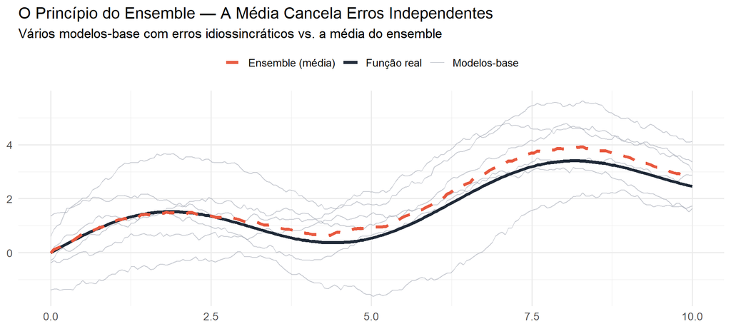

Figure 1: Princípio clássico do ensemble: cada modelo-base (cinza) erra em uma direção diferente; a média (vermelho tracejado) aproxima-se da função real (preto), reduzindo a variância.

```r
set.seed(123)
x_grid <- seq(0, 10, length.out = 200)
truth  <- sin(x_grid) + 0.3 * x_grid

base_preds <- purrr::map_dfr(1:6, function(m) {
  tibble(
    x     = x_grid,
    valor = truth + rnorm(1, 0, 0.7) + sin(x_grid + m) * 0.5 +
            cumsum(rnorm(length(x_grid), 0, 0.07)),
    serie = paste0("Modelo ", m)
  )
})

ens <- base_preds |>
  group_by(x) |>
  summarise(valor = mean(valor), .groups = "drop")

ggplot() +
  geom_line(data = base_preds,
            aes(x, valor, group = serie, color = "Modelos-base"),
            alpha = 0.55, linewidth = 0.5) +
  geom_line(data = tibble(x = x_grid, valor = truth),
            aes(x, valor, color = "Função real"), linewidth = 1.5) +
  geom_line(data = ens,
            aes(x, valor, color = "Ensemble (média)"),
            linewidth = 1.5, linetype = "dashed") +
  scale_color_manual(values = c("Modelos-base"     = "#9CA3AF",
                                "Função real"      = "#1F2937",
                                "Ensemble (média)" = "#E8583E")) +
  labs(title    = "O Princípio do Ensemble — A Média Cancela Erros Independentes",
       subtitle = "Vários modelos-base com erros idiossincráticos vs. a média do ensemble",
       x = NULL, y = NULL, color = NULL) +
  theme_minimal(base_size = 13) +
  theme(legend.position = "top")
```

## 1.3 Estrutura do Projeto

O desafio deste projeto é utilizar uma **base de dados unificada** para construir no mínimo dois modelos: um de **aprendizado supervisionado** e outro **não-supervisionado**. Toda a análise utiliza uma **fonte única de dados: Open-Meteo ERA5 Reanalysis**, garantindo consistência metodológica entre as partes.

Conforme o enunciado, toda a modelagem supervisionada é construída com o stack **`tidymodels`** — `recipes` (pré-processamento sem leakage), `parsnip` (especificação), `workflows` (pipeline), `tune` (otimização de hiperparâmetros) e `yardstick` (métricas) — comparando **Regressão Linear, Random Forest, XGBoost (com tuning via CV) e uma rede neural MLP** (`torch`/`brulee`, item opcional do enunciado), além do **ensemble Regressão Linear + XGBoost**.

|  | **Supervisionado — Regional** | **Não-Supervisionado** |
| --- | --- | --- |
| **Dados** | Open-Meteo ERA5 — painel de **16 municípios** de MT (diário) | Open-Meteo ERA5 — 12 cidades (diário → mensal) |
| **Granularidade** | Diária | Mensal (agregação) |
| **Alvo** | **Temp. máxima de amanhã** (`lead`, por município) **+ alerta de estresse (≥ 35 °C)** | Nenhum — descoberto |
| **Modelos** | PCA · Reg. Linear · RF · XGBoost (tuned) · **Ensemble (RL+XGB)** · MLP — via `tidymodels` | PCA · K-Means · Ward (k = 3) |
| **Métrica** | RMSE · MAE · R² · **precisão/recall do alerta** (`yardstick`) | Variância explicada · Silhouette |

A pergunta central de cada parte é diferente:

- **Supervisionado:** *“Consigo prever a temperatura máxima de amanhã — e disparar um alerta de estresse térmico — para qualquer município produtor de MT?”*
- **Não-supervisionado:** *“Existem zonas climáticas naturais no Brasil — e onde o Centro-Oeste/Cerrado se posiciona?”*

Além disso, investigamos uma questão complementar:

- **Dinâmica dos clusters:** *“As zonas climáticas estão mudando ao longo do tempo?”*

# 2 Dados e Análise Exploratória

Toda a análise usa **Open-Meteo ERA5 Reanalysis**. O dado supervisionado é o **painel diário (1980–2024) de 16 municípios produtores de soja/milho de Mato Grosso** — `temp_max`, `temp_min`, precipitação, vento e radiação por dia, mais a **elevação** de cada ponto. Antes de modelar, exploramos **onde** o risco se concentra no espaço, em dois eixos de disrupção de oferta: **calor** (estresse térmico) e **chuva** (déficit hídrico).

**Note**

**Pipeline de dados:** `fetch_mt_panel.py` baixa o diário dos municípios (painel supervisionado, com elevação); `fetch_mt_points.py` e `fetch_mt_precip.py` produzem os resumos espaciais compactos dos mapas (`data/mt_points_*.csv`). A geometria de MT vem da malha oficial do **IBGE**. A base supervisionada de Sorriso, de versões anteriores, foi substituída por este painel regional.

**Ver código**

```r
# Mantemos só os 16 municípios com painel diário completo (mesma base do modelo regional)
munis_16 <- read_csv("data/mt_panel_meta.csv", show_col_types = FALSE)$city
pts_hs <- read_csv("data/mt_points_heatstress.csv", show_col_types = FALSE) |> filter(city %in% munis_16)
pts_pr <- read_csv("data/mt_points_precip90.csv",   show_col_types = FALSE) |> filter(city %in% munis_16)
janela <- sprintf("%s a %s", pts_pr$window_start[1], pts_pr$window_end[1])

# Geometria oficial de Mato Grosso (IBGE): contorno do estado + malha municipal
mt_uf  <- sf::st_read("data/geo/mt_uf.json",  quiet = TRUE)
mt_mun <- sf::st_read("data/geo/mt_mun.json", quiet = TRUE)

# Camada-base reutilizável dos mapas (malha municipal cinza + contorno do estado)
base_mt <- list(
  geom_sf(data = mt_mun, fill = "gray97", color = "gray86",
          linewidth = 0.15, inherit.aes = FALSE),
  geom_sf(data = mt_uf,  fill = NA, color = "gray35",
          linewidth = 0.6, inherit.aes = FALSE)
)

cat(sprintf("%d municípios | janela de precipitação = últimos 90 dias do período do estudo: %s\n",
            nrow(pts_hs), janela))
```

```
16 municípios | janela de precipitação = últimos 90 dias do período do estudo: 2024-10-03 a 2024-12-31
```

## 2.1 Risco de Calor — Estresse Térmico no Espaço

Cada município é posicionado por longitude/latitude; **cor e tamanho** codificam o risco (dias/ano com `temp_max ≥ 35 °C`). Sorriso — município de referência do agronegócio — está destacado com contorno preto.

**Ver código**

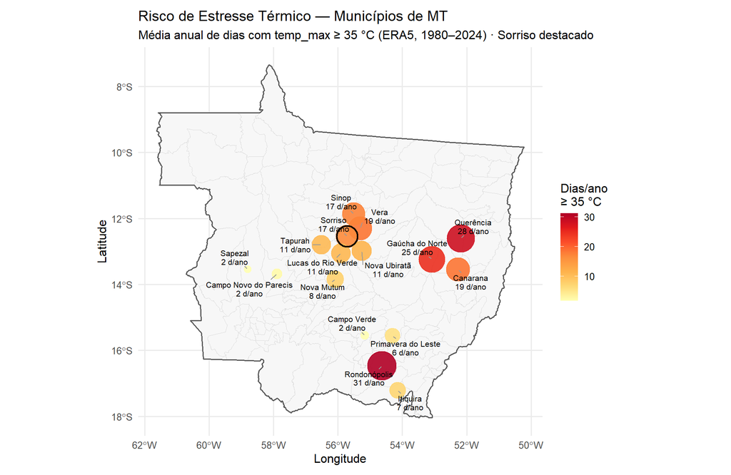

Figure 2: Risco de estresse térmico nos municípios produtores de MT. Tons quentes e pontos maiores = mais dias de calor extremo por ano. O oeste (Chapada dos Parecis, mais alto) é o mais ameno; leste e sul concentram o maior risco.

```r
sorriso_hs <- pts_hs |> filter(city == "Sorriso")

ggplot(pts_hs, aes(lon, lat)) +
  base_mt +
  geom_point(aes(color = days_ge35, size = days_ge35), alpha = 0.9) +
  geom_point(data = sorriso_hs, shape = 21, size = 9, stroke = 1.3,
             color = "black", fill = NA) +
  geom_text_repel(aes(label = sprintf("%s\n%.0f d/ano", city, days_ge35)),
                  size = 2.8, lineheight = 0.9, segment.color = "gray60",
                  min.segment.length = 0, max.overlaps = 20, seed = 1) +
  scale_color_distiller(palette = "YlOrRd", direction = 1, name = "Dias/ano\n≥ 35 °C") +
  scale_size_continuous(range = c(3, 13), guide = "none") +
  coord_sf(expand = TRUE) +
  labs(title    = "Risco de Estresse Térmico — Municípios de MT",
       subtitle = "Média anual de dias com temp_max ≥ 35 °C (ERA5, 1980–2024) · Sorriso destacado",
       x = "Longitude", y = "Latitude") +
  theme_minimal(base_size = 12) +
  theme(panel.grid.minor = element_blank(), plot.margin = margin(10, 30, 10, 10))
```

**ImportantLeitura espacial do calor**

## 2.2 Risco Hídrico — Precipitação Acumulada (Últimos 90 Dias)

A outra face da disrupção de safra é a **falta de chuva**: veranicos e déficit hídrico estressam soja e milho tanto quanto o calor. Usamos um recorte de **90 dias dentro da própria base do estudo** — 2024-10-03 a 2024-12-31, ou seja, o **início da safra 2024/25**, quando o plantio da soja depende do *onset* das chuvas. Mapeamos a chuva acumulada nesse período e, mais importante, o quanto ela representa da **normal climatológica 1991–2020** — porque, no pico das chuvas, o valor absoluto sozinho confunde sazonalidade com anomalia.

**Ver código**

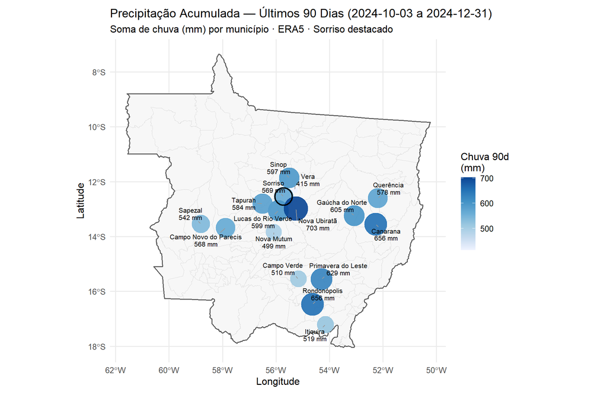

Figure 3: Chuva acumulada (mm) nos últimos 90 dias por município. Azul mais escuro = mais chuva no período.

```r
sorriso_pr <- pts_pr |> filter(city == "Sorriso")

ggplot(pts_pr, aes(lon, lat)) +
  base_mt +
  geom_point(aes(color = precip_90d, size = precip_90d), alpha = 0.9) +
  geom_point(data = sorriso_pr, shape = 21, size = 9, stroke = 1.3,
             color = "black", fill = NA) +
  geom_text_repel(aes(label = sprintf("%s\n%.0f mm", city, precip_90d)),
                  size = 2.8, lineheight = 0.9, segment.color = "gray60",
                  min.segment.length = 0, max.overlaps = 20, seed = 1) +
  scale_color_distiller(palette = "Blues", direction = 1, name = "Chuva 90d\n(mm)") +
  scale_size_continuous(range = c(3, 13), guide = "none") +
  coord_sf(expand = TRUE) +
  labs(title    = paste0("Precipitação Acumulada — Últimos 90 Dias (", janela, ")"),
       subtitle = "Soma de chuva (mm) por município · ERA5 · Sorriso destacado",
       x = "Longitude", y = "Latitude") +
  theme_minimal(base_size = 12) +
  theme(panel.grid.minor = element_blank(), plot.margin = margin(10, 30, 10, 10))
```

**Ver código**

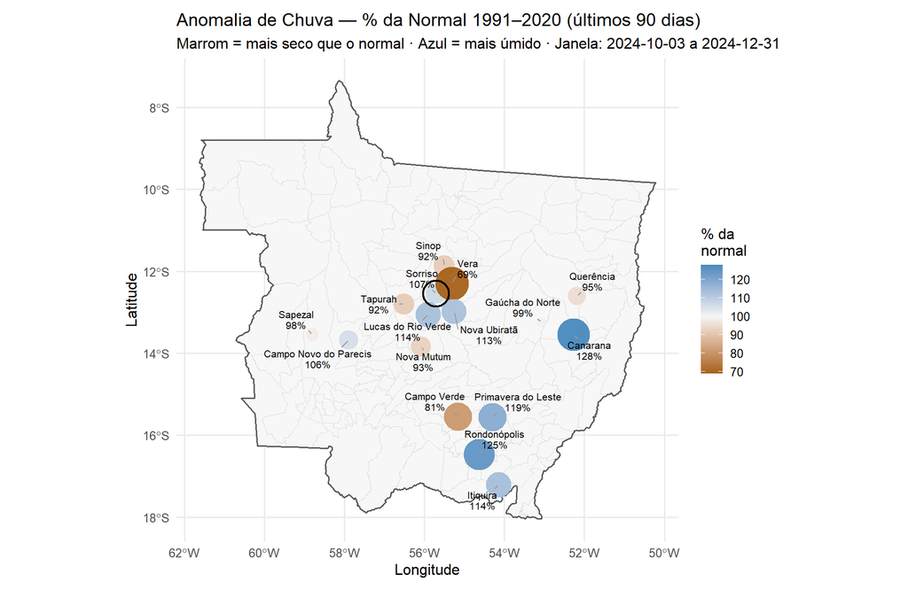

Figure 4: Anomalia de chuva: precipitação dos últimos 90 dias como % da normal 1991–2020. Marrom = mais seco que o normal (risco hídrico); azul = mais úmido. O tamanho do ponto cresce com a magnitude da anomalia.

```r
ggplot(pts_pr, aes(lon, lat)) +
  base_mt +
  geom_point(aes(color = pct_normal, size = abs(pct_normal - 100) + 25), alpha = 0.95) +
  geom_point(data = sorriso_pr, shape = 21, size = 9, stroke = 1.3,
             color = "black", fill = NA) +
  geom_text_repel(aes(label = sprintf("%s\n%.0f%%", city, pct_normal)),
                  size = 2.8, lineheight = 0.9, segment.color = "gray60",
                  min.segment.length = 0, max.overlaps = 20, seed = 1) +
  scale_color_gradient2(low = "#A6611A", mid = "#F5F5F5", high = "#2C7FB8",
                        midpoint = 100, name = "% da\nnormal") +
  scale_size_continuous(range = c(3, 12), guide = "none") +
  coord_sf(expand = TRUE) +
  labs(title    = "Anomalia de Chuva — % da Normal 1991–2020 (últimos 90 dias)",
       subtitle = paste0("Marrom = mais seco que o normal · Azul = mais úmido · Janela: ", janela),
       x = "Longitude", y = "Latitude") +
  theme_minimal(base_size = 12) +
  theme(panel.grid.minor = element_blank(), plot.margin = margin(10, 30, 10, 10))
```

**ImportantLeitura espacial da chuva**

Neste recorte (início da safra 2024/25), as chuvas vieram **próximas ou acima da normal** na maior parte de MT — um *onset* de estação chuvosa sem grandes atrasos. Os déficits são **localizados**: **Vera (~69 % da normal)** e **Campo Verde (~81 %)** foram as secas mais claras; no extremo úmido, **Canarana (128 %)**, **Rondonópolis (125 %)** e **Primavera do Leste (119 %)**. Sorriso fechou em **~107 % da normal**. O mapa de anomalia (% da normal) é mais informativo que o de mm absolutos: como out–dez é o pico das chuvas, todos os pontos somam centenas de mm — o que **move o risco** é o desvio da normal, não o total acumulado.

## 2.3 Calor + Seca — Risco Combinado

**Ver código**

```r
pts_hs |>
  select(city, lat, lon, days_ge35) |>
  left_join(pts_pr |> select(city, precip_90d, pct_normal), by = "city") |>
  arrange(desc(days_ge35)) |>
  transmute(Município = city,
            `Dias/ano ≥ 35 °C` = days_ge35,
            `Chuva 90d (mm)`   = precip_90d,
            `% da normal`      = pct_normal) |>
  knitr::kable(caption = sprintf(
    "Risco combinado por município — calor (1980–2024) e chuva (%s)", janela))
```

Table 1: Risco combinado por município — calor (1980–2024) e chuva (2024-10-03 a 2024-12-31)

| Município | Dias/ano ≥ 35 °C | Chuva 90d (mm) | % da normal |
| --- | --- | --- | --- |
| Rondonópolis | 31.2 | 656.5 | 124.8 |
| Querência | 28.4 | 577.8 | 95.1 |
| Gaúcha do Norte | 24.7 | 605.2 | 99.0 |
| Canarana | 18.6 | 656.4 | 128.0 |
| Vera | 18.6 | 414.8 | 69.1 |
| Sinop | 17.3 | 596.9 | 91.9 |
| Sorriso | 16.8 | 568.9 | 106.9 |
| Nova Ubiratã | 11.4 | 703.1 | 113.2 |
| Lucas do Rio Verde | 10.9 | 598.8 | 113.7 |
| Tapurah | 10.6 | 584.3 | 91.8 |
| Nova Mutum | 7.7 | 498.7 | 92.8 |
| Itiquira | 7.1 | 518.9 | 114.0 |
| Primavera do Leste | 5.6 | 628.9 | 119.0 |
| Campo Novo do Parecis | 2.4 | 568.2 | 105.8 |
| Campo Verde | 1.9 | 510.1 | 81.0 |
| Sapezal | 1.8 | 542.2 | 98.3 |

**WarningOnde os dois riscos se somam**

O risco de safra mais preocupante é a **coincidência** de calor alto e chuva abaixo do normal. Neste início de safra, as chuvas vieram **adequadas** na maioria dos municípios, de modo que o estresse dominante foi o **térmico** — concentrado no **leste/sul** (Rondonópolis, Querência, Gaúcha do Norte) e no **centro-norte** (Vera, Sinop). O caso de **dupla exposição** mais nítido é **Vera**: alto estresse térmico (~19 dias/ano) **e** o maior déficit de chuva do recorte (~69 % da normal). O **oeste do Parecis** segue o mais resiliente (ameno e bem suprido de chuva). A leitura prática para o agente de commodities: cruzar a **anomalia hídrica de 90 dias** com o alerta térmico regional e **reponderar por sub-região** o sinal previsto para cada município.

# 3 Parte I — Análise Supervisionada Regional (Máxima de Amanhã em Todo o Mato Grosso)

Esta é a análise supervisionada central. Em vez de um único ponto, treinamos **um modelo regional** sobre o **painel dos 16 municípios**, prevendo a **temperatura máxima de amanhã** para qualquer um deles. Aplicamos aqui toda a metodologia — **PCA**, features **cross-sectional de Fourier**, **Regressão Linear**, **Random Forest**, **XGBoost com tuning**, o **Ensemble (Regressão Linear + XGBoost)** e uma **rede neural (MLP)**, tudo via `tidymodels` — e fechamos com a **camada de decisão** (alerta de estresse térmico).

**NotePainel, lat/lon/elevação e prevenção de leakage**

O `lead` da máxima é calculado **dentro de cada município**; o split é **cronológico** (treino < 2023, teste ≥ 2023). No total são **262.976 dias-município**: **251.296 no treino** (até 2022) e **11.680 no teste** (2023–2024). Além do clima do dia e da sazonalidade de Fourier, o modelo recebe **latitude, longitude e elevação** — a **altitude** é o que torna a Chapada dos Parecis mais fria. Dos 20 municípios mapeados, **16 têm painel diário completo** (os outros 4 ficaram limitados pela API na coleta).

**Ver código**

```r
panel      <- read_csv("data/mt_panel_daily.csv", show_col_types = FALSE) |> mutate(date = as.Date(date))
panel_meta <- read_csv("data/mt_panel_meta.csv",  show_col_types = FALSE)

feat_reg <- panel |>
  arrange(city, date) |> group_by(city) |>
  mutate(
    target = lead(temp_max, 1),
    doy = yday(date), n_days = if_else(leap_year(date), 366, 365),
    sin1 = sin(2*pi*doy/n_days), cos1 = cos(2*pi*doy/n_days),
    sin2 = sin(4*pi*doy/n_days), cos2 = cos(4*pi*doy/n_days),
    temp_range = temp_max - temp_min, precip_rad_ratio = precip / (radiation + 1)
  ) |> ungroup() |> left_join(panel_meta, by = "city") |> drop_na(target)

feats_reg <- c("temp_max","temp_min","temp_range","precip","wind_max","radiation",
               "precip_rad_ratio","sin1","cos1","sin2","cos2","lat","lon","elevation")
train_reg <- feat_reg |> filter(date <  cutoff)
test_reg  <- feat_reg |> filter(date >= cutoff)
trs_reg   <- train_reg |> select(all_of(c(feats_reg, "target")))
cat(sprintf("Painel: %s linhas | treino %s | teste %s | %d municípios\n",
            format(nrow(feat_reg), big.mark="."), format(nrow(train_reg), big.mark="."),
            format(nrow(test_reg), big.mark="."), n_distinct(feat_reg$city)))
```

```
Painel: 262.976 linhas | treino 251.296 | teste 11.680 | 16 municípios
```

## 3.1 Qualidade dos Dados — Cobertura, Faltantes e Discrepantes

Antes de modelar, auditamos a base quanto a **faltantes**, **valores fisicamente implausíveis** e **cobertura espacial**. Por ser uma **reanálise** (ERA5) — e não uma estação meteorológica bruta — a série é regular e sem buracos, o que muda o tipo de cuidado necessário.

Auditoria das variáveis do painel (16 municípios, 1980–2024)

| Variável | Faltantes | Mínimo | Máximo |
| --- | --- | --- | --- |
| temp_max | 0 | 10.0 | 41.3 |
| temp_min | 0 | 4.2 | 28.8 |
| precip | 0 | 0.0 | 183.6 |
| wind_max | 0 | 2.9 | 37.6 |
| radiation | 0 | 1.9 | 31.0 |

**NoteDecisões de tratamento de dados**

- **Faltantes:** o painel ERA5 não tem buracos internos. O único `drop_na` é sobre o **alvo** (`lead(temp_max)`), que remove o **último dia de cada município** (sem dia seguinte) — 16 linhas, isto é, **1 por município**. **Nenhuma imputação** é necessária.
- **Discrepantes:** as faixas físicas são plausíveis (sem temperaturas impossíveis nem precipitação negativa). Crucialmente, **não removemos os extremos de calor**: eles **são o próprio sinal** que queremos prever (estresse térmico). Filtrá-los como *outliers* destruiria o objetivo de negócio — decisão deliberada e oposta ao reflexo estatístico usual.
- **Cobertura espacial (viés de seleção):** dos 20 municípios mapeados, **4 ficaram sem painel diário** por limite de requisições da API — *Campos de Júlio, Diamantino, Tangará da Serra* e *Brasnorte*, concentrados no **oeste/noroeste** (Chapada dos Parecis). Como essa é justamente a sub-região **mais amena**, os 16 restantes podem **superestimar levemente** o calor médio do estado. Ainda assim, cobrem todo o gradiente (oeste ameno → sul/leste quente), e o mapa de RMSE por município mostra desempenho homogêneo — o viés afeta a *representatividade*, não a *validade* do modelo onde há dados.

## 3.2 Sazonalidade Cíclica — Termos de Fourier

A previsão é **cross-sectional**: cada dia é uma observação independente (clima de hoje + posição no ciclo anual), sem usar o histórico da própria série. O desafio é representar a sazonalidade, que é **cíclica** — dezembro e janeiro são termicamente adjacentes, mas qualquer índice linear (`month` 1–12, `doy` 1–365) os coloca em extremos opostos. Projetamos então o dia do ano no **círculo unitário** com pares seno/cosseno:

$$\sin_k = \sin\!\left(\frac{2\pi k\,\text{doy}}{N}\right), \qquad
\cos_k = \cos\!\left(\frac{2\pi k\,\text{doy}}{N}\right)$$

- **$k = 1$ (ciclo anual):** a oscilação principal verão/inverno.
- **$k = 2$ (ciclo semianual):** assimetrias dentro do ano, como o contraste seca/chuva do Cerrado.

| Representação | Sazonalidade | Problema |
| --- | --- | --- |
| `month` / `doy` | numérica | Dez (12) e Jan (1) ficam a 11 unidades de distância |
| one-hot de mês | 11 dummies | sem suavidade; cada mês é independente |
| **Fourier sin/cos** | **contínua e cíclica** | **Jan e Dez ficam naturalmente próximos** |

**TipPor que sin **e** cos juntos?**

Um único $\sin_1$ fixaria o pico em um dia do ano. Com $\cos_1$ junto, a combinação $a\sin_1 + b\cos_1$ **ajusta a fase livremente** — o máximo cai em qualquer dia conforme a razão $b/a$:

$$a\sin\theta + b\cos\theta = \sqrt{a^2 + b^2}\;\sin\!\left(\theta + \arctan\tfrac{b}{a}\right)$$

Em Mato Grosso, onde a **máxima térmica ocorre em ago–set** (fim da estação seca) e não no verão chuvoso, é o $\cos_1$ que permite aos modelos posicionar corretamente esse pico de primavera.

**Ver código**

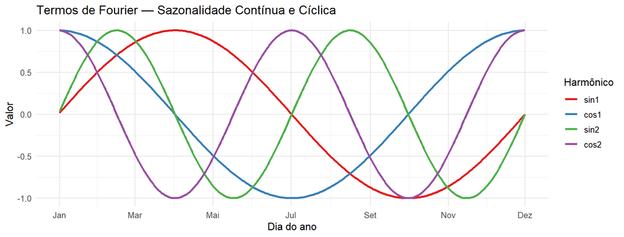

Figure 5: Os quatro termos de Fourier ao longo do ano (iguais para todos os municípios). Substituem month/doy e mantêm janeiro e dezembro contíguos.

```r
tibble(doy = 1:365) |>
  mutate(sin1 = sin(2*pi*doy/365), cos1 = cos(2*pi*doy/365),
         sin2 = sin(4*pi*doy/365), cos2 = cos(4*pi*doy/365)) |>
  pivot_longer(-doy, names_to = "harmonico", values_to = "valor") |>
  mutate(harmonico = factor(harmonico, levels = c("sin1","cos1","sin2","cos2"))) |>
  ggplot(aes(doy, valor, color = harmonico)) +
  geom_line(linewidth = 1.1) +
  scale_color_brewer(palette = "Set1") +
  scale_x_continuous(breaks = c(1,60,121,182,244,305,365),
                     labels = c("Jan","Mar","Mai","Jul","Set","Nov","Dez")) +
  labs(title = "Termos de Fourier — Sazonalidade Contínua e Cíclica",
       x = "Dia do ano", y = "Valor", color = "Harmônico") +
  theme_minimal(base_size = 12)
```

### 3.2.1 A Base Após os Termos de Fourier

A tabela abaixo mostra como a base fica depois de adicionar a sazonalidade de Fourier — uma amostra de um município (Sorriso) ao longo do ano. Cada linha é uma observação **independente**: o modelo recebe o clima do dia, a posição no ciclo anual (`sin/cos`) e a geografia do ponto (`lat`/`lon`/`elevation`), sem nenhum valor passado da própria série.

**Ver código**

```r
feat_reg |>
  filter(city == "Sorriso", year(date) == 2001,
         doy %in% c(15, 74, 135, 196, 257, 319, 349)) |>
  transmute(
    Município     = city,
    Data          = date,
    doy,
    `T. máx (°C)` = round(temp_max, 1),
    sin1          = round(sin1, 3),
    cos1          = round(cos1, 3),
    sin2          = round(sin2, 3),
    cos2          = round(cos2, 3),
    `Elev. (m)`   = elevation,
    `Alvo amanhã` = round(target, 1)
  ) |>
  knitr::kable(align = "c",
    caption = "Amostra da base regional após Fourier (Sorriso, um dia por bimêstre de 2001). Note que janeiro (doy 15) e dezembro (doy 349) têm cos1 quase igual — ficam adjacentes no círculo anual.")
```

Amostra da base regional após Fourier (Sorriso, um dia por bimêstre de 2001). Note que janeiro (doy 15) e dezembro (doy 349) têm cos1 quase igual — ficam adjacentes no círculo anual.

| Município | Data | doy | T. máx (°C) | sin1 | cos1 | sin2 | cos2 | Elev. (m) | Alvo amanhã |
| --- | --- | --- | --- | --- | --- | --- | --- | --- | --- |
| Sorriso | 2001-01-15 | 15 | 30.0 | 0.255 | 0.967 | 0.494 | 0.870 | 365 | 29.2 |
| Sorriso | 2001-03-15 | 74 | 24.3 | 0.956 | 0.293 | 0.560 | -0.829 | 365 | 29.2 |
| Sorriso | 2001-05-15 | 135 | 30.5 | 0.730 | -0.684 | -0.998 | -0.065 | 365 | 31.2 |
| Sorriso | 2001-07-15 | 196 | 33.1 | -0.230 | -0.973 | 0.448 | 0.894 | 365 | 32.4 |
| Sorriso | 2001-09-14 | 257 | 29.5 | -0.959 | -0.284 | 0.545 | -0.838 | 365 | 29.9 |
| Sorriso | 2001-11-15 | 319 | 31.1 | -0.712 | 0.703 | -1.000 | -0.013 | 365 | 31.7 |
| Sorriso | 2001-12-15 | 349 | 29.5 | -0.272 | 0.962 | -0.523 | 0.852 | 365 | 30.3 |

## 3.3 PCA — Estrutura das Variáveis Meteorológicas

O **PCA** comprime as 5 variáveis meteorológicas correlacionadas em componentes ortogonais. Aqui ele tem papel **exploratório**: revela a estrutura latente do clima do painel. Como os modelos de árvore e a MLP lidam nativamente com correlação, as features brutas (não os PCs) alimentam a previsão — o PCA agrega mais à compreensão do que ao RMSE.

**Ver código**

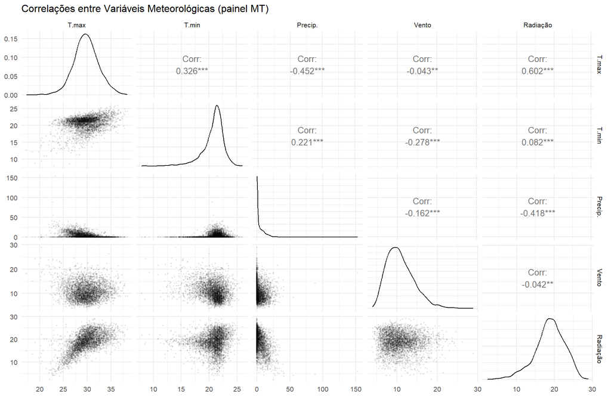

```r
set.seed(1)
train_reg |> slice_sample(n = 4000) |>
  select(temp_max, temp_min, precip, wind_max, radiation) |>
  GGally::ggpairs(columnLabels = c("T.max","T.min","Precip.","Vento","Radiação"),
                  lower = list(continuous = GGally::wrap("points", alpha = 0.08, size = 0.4)),
                  upper = list(continuous = GGally::wrap("cor", size = 3.5)),
                  title = "Correlações entre Variáveis Meteorológicas (painel MT)") +
  theme_minimal(base_size = 10)
```

**Ver código**

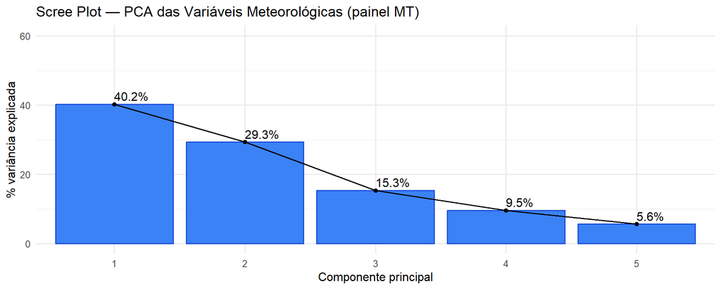

Scree plot do PCA das 5 variáveis meteorológicas no painel de treino. Os 3 primeiros componentes concentram a maior parte da variância.

```r
wf5 <- c("temp_max","temp_min","precip","wind_max","radiation")
pca_reg <- prcomp(train_reg[wf5], center = TRUE, scale. = TRUE)
factoextra::fviz_eig(pca_reg, addlabels = TRUE, barfill = "#3B82F6", barcolor = "#1D4ED8",
                     ylim = c(0, 60)) +
  labs(title = "Scree Plot — PCA das Variáveis Meteorológicas (painel MT)",
       x = "Componente principal", y = "% variância explicada") +
  theme_minimal(base_size = 12)
```

**Ver código**

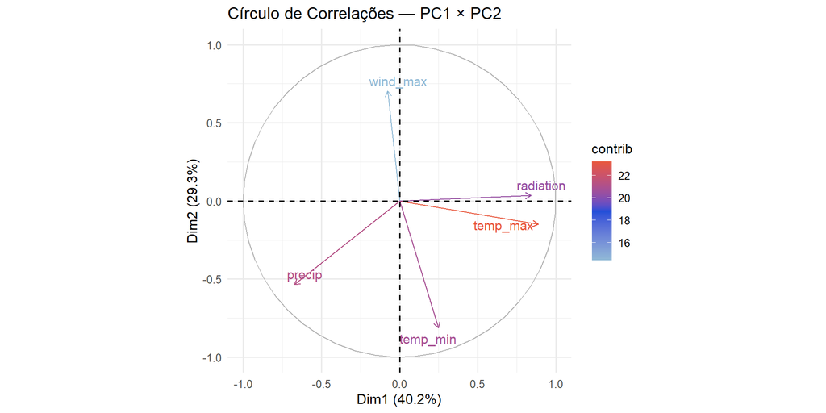

Círculo de correlações: direção e contribuição de cada variável nos dois primeiros componentes.

```r
factoextra::fviz_pca_var(pca_reg, repel = TRUE, col.var = "contrib",
                         gradient.cols = c("#91BAD6", "#1D4ED8", "#E8583E"),
                         title = "Círculo de Correlações — PC1 × PC2") +
  theme_minimal(base_size = 12)
```

### 3.3.1 PCA Ajuda na Previsão? — PCA vs Features Brutas

Reduzir dimensão é útil quando há **muitas** features redundantes. Aqui temos só **5 variáveis meteorológicas** — então comprimi-las pode **descartar sinal**. Testamos: treinamos Regressão Linear e Random Forest com as **5 variáveis brutas** e com seus **3 primeiros componentes** (≈ 85% da variância), mantendo Fourier e geografia iguais.

**Ver código**

```r
wf5_cmp   <- c("temp_max","temp_min","precip","wind_max","radiation")
feats_cmp <- c(wf5_cmp, "sin1","cos1","sin2","cos2","lat","lon","elevation")
tr_cmp    <- train_reg |> select(all_of(c(feats_cmp, "target")))

rec_raw_cmp <- recipe(target ~ ., data = tr_cmp) |> step_normalize(all_numeric_predictors())
rec_pca_cmp <- recipe(target ~ ., data = tr_cmp) |>
  step_normalize(all_of(wf5_cmp)) |> step_pca(all_of(wf5_cmp), num_comp = 3) |>
  step_normalize(all_numeric_predictors())

lin_cmp <- linear_reg() |> set_engine("lm")
rf_cmp  <- rand_forest(trees = 300, mode = "regression") |> set_engine("ranger", num.threads = n_cores)

fit_one <- function(rec, spec) { set.seed(1); wf <- workflow(rec, spec) |> fit(tr_cmp)
  rmse(predict(wf, test_reg)$.pred, test_reg$target) }
pca_raw <- tibble(
  Algoritmo = rep(c("Regressão Linear","Random Forest"), each = 2),
  Tipo      = rep(c("Sem PCA (5 variáveis)","Com PCA (3 PCs)"), 2),
  RMSE      = c(fit_one(rec_raw_cmp, lin_cmp), fit_one(rec_pca_cmp, lin_cmp),
                fit_one(rec_raw_cmp, rf_cmp),  fit_one(rec_pca_cmp, rf_cmp))
)
```

**Ver código**

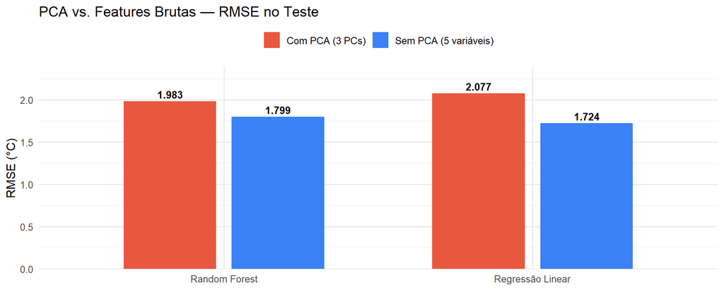

Figure 6: RMSE no teste com as 5 variáveis brutas vs. seus 3 primeiros componentes principais. Em ambos os algoritmos o PCA PIORA o erro — com poucas variáveis, reduzir dimensão descarta sinal útil.

```r
pca_raw |>
  ggplot(aes(Algoritmo, RMSE, fill = Tipo)) +
  geom_col(position = position_dodge(0.7), width = 0.6) +
  geom_text(aes(label = round(RMSE, 3)), position = position_dodge(0.7),
            vjust = -0.4, size = 3.6, fontface = "bold") +
  scale_fill_manual(values = c("Sem PCA (5 variáveis)" = "#3B82F6", "Com PCA (3 PCs)" = "#E8583E")) +
  scale_y_continuous(expand = expansion(mult = c(0, 0.15))) +
  labs(title = "PCA vs. Features Brutas — RMSE no Teste", x = NULL, y = "RMSE (°C)", fill = NULL) +
  theme_minimal(base_size = 12) + theme(legend.position = "top")
```

**ImportantQuando o PCA ajuda — e quando atrapalha**

| Situação | PCA ajuda? |
| --- | --- |
| Muitas features redundantes (dezenas/centenas) | **Sim** — remove ruído e multicolinearidade |
| **Poucas variáveis, todas informativas (nosso caso)** | **Não** — reduzir dimensão **descarta sinal** |
| Visualização 2D/3D | **Sempre** — comprime para inspeção |
| Árvores / boosting com features correlacionadas | **Pouco** — já tratam correlação nativamente |

Com apenas **5 variáveis meteorológicas**, todas úteis, comprimi-las em 3 PCs **piora** o RMSE nos dois algoritmos — e mesmo com 4 PCs (94% da variância) ainda perde. A lição: **o PCA é valioso como ferramenta exploratória** (estrutura e visualização, como acima), **mas não como pré-processamento preditivo aqui**. Por isso os modelos finais usam as **features brutas**, não os componentes — mais dimensões, neste caso, significam mais informação.

## 3.4 Modelos — Apresentação

Comparamos cinco abordagens, todas em `tidymodels` (recipe + parsnip + workflow) e treinadas no mesmo painel. **Apresentamos cada modelo aqui**; os **resultados** (erro **e** recall) vêm na seção Resultados e Comparação.

| Modelo | O que é | Característica |
| --- | --- | --- |
| **Regressão Linear** | uma equação linear global | alto viés, baixa variância; extrapola |
| **Random Forest** | média de muitas árvores (*bagging*) | baixa variância; não extrapola |
| **XGBoost (tuned)** | árvores sequenciais (*boosting*) + tuning por CV | baixo viés; referência em dados tabulares |
| **Ensemble (Reg. Linear + XGBoost)** | média dos dois mais opostos | erros decorrelacionados → menor RMSE |
| **Rede Neural (MLP)** | perceptron multicamadas (`torch`) | capta não-linearidades; item opcional |

O código abaixo ajusta todos os modelos; em seguida detalhamos o **tuning do XGBoost**, a **arquitetura da MLP** e a **interpretabilidade (SHAP)** — e só então comparamos os resultados.

**Ver código**

```r
rec_reg <- recipe(target ~ ., data = trs_reg) |>
  step_zv(all_predictors()) |> step_normalize(all_numeric_predictors())

lin_spec <- linear_reg() |> set_engine("lm")
rf_spec  <- rand_forest(trees = 400, mode = "regression") |>
  set_engine("ranger", importance = "impurity", num.threads = n_cores)
lin_fit <- workflow(rec_reg, lin_spec) |> fit(trs_reg)
set.seed(1); rf_fit_reg <- workflow(rec_reg, rf_spec) |> fit(trs_reg)
p_lin <- predict(lin_fit,    test_reg)$.pred
p_rf  <- predict(rf_fit_reg, test_reg)$.pred

# XGBoost com tuning (CV) — sem normalização (árvores são invariantes à escala).
# Grid simples sobre os três hiperparâmetros principais.
rec_x <- recipe(target ~ ., data = trs_reg) |> step_zv(all_predictors())
xgb_spec <- boost_tree(trees = tune(), tree_depth = tune(), learn_rate = tune()) |>
  set_engine("xgboost", nthread = n_cores) |> set_mode("regression")
xgb_grid <- crossing(learn_rate = c(0.05, 0.1), trees = c(500, 900), tree_depth = c(4, 6))
set.seed(1)
xgb_tuned   <- tune_grid(workflow(rec_x, xgb_spec), resamples = vfold_cv(trs_reg, v = 3),
                         grid = xgb_grid, metrics = metric_set(yardstick::rmse))
best_xgb    <- select_best(xgb_tuned, metric = "rmse")
xgb_fit_reg <- workflow(rec_x, xgb_spec) |> finalize_workflow(best_xgb) |> fit(trs_reg)
p_xgb <- predict(xgb_fit_reg, test_reg)$.pred

# Ensemble: Regressão Linear + XGBoost (média simples)
p_ens <- (p_lin + p_xgb) / 2

# MLP (torch/brulee) — item opcional do enunciado
have_torch <- requireNamespace("brulee", quietly = TRUE) &&
              isTRUE(tryCatch(torch::torch_is_installed(), error = function(e) FALSE))
if (have_torch) {
  mlp_spec <- mlp(hidden_units = 64, dropout = 0.10, epochs = 60, learn_rate = 0.05,
                  activation = "relu") |>
    set_engine("brulee", optimizer = "SGD", momentum = 0.9, batch_size = 1024L,
               validation = 0.20, stop_iter = 8L) |>
    set_mode("regression")
  set.seed(1); mlp_fit_reg <- workflow(rec_reg, mlp_spec) |> fit(trs_reg)
  p_mlp <- predict(mlp_fit_reg, test_reg)$.pred
}

cat(sprintf("XGBoost — melhores hiperparâmetros: trees=%d | depth=%d | eta=%.2f\n",
            best_xgb$trees, best_xgb$tree_depth, best_xgb$learn_rate))
```

```
XGBoost — melhores hiperparâmetros: trees=900 | depth=6 | eta=0.10
```

**ImportantPor que o Ensemble Regressão Linear + XGBoost**

O **Ensemble** combina os modelos mais **estruturalmente opostos** — uma equação linear global (alto viés, baixa variância) e árvores *boosted* (baixo viés). Como erram de formas diferentes, a **média simples** tende a ficar abaixo de cada um isolado. Seu ganho real — e o de cada modelo — aparece na comparação de resultados adiante.

### 3.4.1 Otimização de Hiperparâmetros do XGBoost

O XGBoost é o modelo com hiperparâmetros **otimizados por busca**. Varremos um **grid** sobre três parâmetros — taxa de aprendizado (`learn_rate`/eta), número de árvores (`trees`) e profundidade das árvores (`tree_depth`) — com **validação cruzada de 3 folds** sobre o treino, escolhendo a combinação de **menor RMSE médio**. O teste (2023–2024) permanece intocado até a avaliação final.

**Ver código**

```r
show_best(xgb_tuned, metric = "rmse", n = 6) |>
  select(learn_rate, trees, tree_depth, mean, std_err) |>
  knitr::kable(digits = 4,
               caption = "Top 6 combinações do grid — RMSE médio em validação cruzada (3 folds) no treino")
```

Top 6 combinações do grid — RMSE médio em validação cruzada (3 folds) no treino

| learn_rate | trees | tree_depth | mean | std_err |
| --- | --- | --- | --- | --- |
| 0.10 | 900 | 6 | 1.3547 | 0.0016 |
| 0.10 | 500 | 6 | 1.3649 | 0.0022 |
| 0.05 | 900 | 6 | 1.3655 | 0.0023 |
| 0.10 | 900 | 4 | 1.3763 | 0.0010 |
| 0.05 | 500 | 6 | 1.3773 | 0.0022 |
| 0.10 | 500 | 4 | 1.3864 | 0.0014 |

**Ver código**

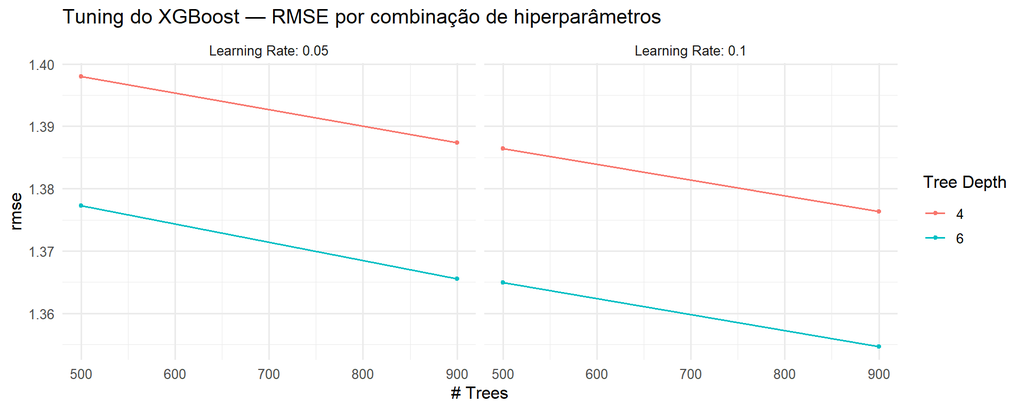

Figure 7: Desempenho (RMSE em CV) ao longo do grid de hiperparâmetros do XGBoost. Cada painel/linha isola o efeito de um parâmetro.

```r
autoplot(xgb_tuned) +
  labs(title = "Tuning do XGBoost — RMSE por combinação de hiperparâmetros") +
  theme_minimal(base_size = 12)
```

### 3.4.2 Rede Neural (MLP) — Arquitetura e Treino

A rede neural (item opcional do enunciado) é um **Multi-Layer Perceptron** totalmente conectado, especificado em `tidymodels` via `parsnip::mlp()` com engine **`brulee`** — a interface **`torch`** nativa em R (libtorch), **sem dependência de Python**:

- **Entrada:** as 14 features numéricas (clima do dia + Fourier + `lat`/`lon`/`elevation`), normalizadas pelo `recipe`.
- **Camada oculta:** 64 neurônios com ativação **ReLU** e **dropout** de 10% (regularização).
- **Saída:** 1 neurônio linear (regressão da máxima de amanhã).
- **Treino:** SGD com *momentum* (0,9), *mini-batches* de 1024 e **early stopping** sobre 20% de validação — interrompe quando a perda de validação para de cair.

**TipPré-requisito: backend torch**

`brulee` usa o **torch** nativo (libtorch), sem Python. Para instalar, rode uma vez: `install.packages(c("torch","brulee"))` e `torch::install_torch()` (baixa o backend, ~100 MB). Se o backend não estiver disponível no ambiente, a seção da MLP é **ignorada automaticamente** e os demais modelos permanecem válidos.

**Ver código**

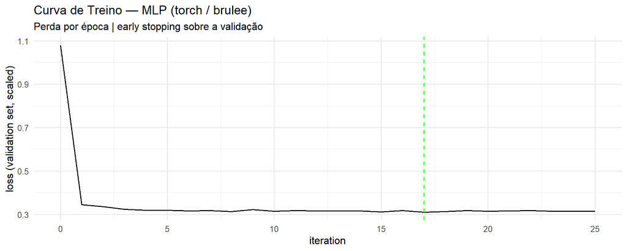

Figure 8: Curva de aprendizado da MLP: perda (MSE) por época. O early stopping interrompe o treino quando a perda de validação para de melhorar, evitando overfitting.

```r
autoplot(extract_fit_engine(mlp_fit_reg)) +
  labs(title = "Curva de Treino — MLP (torch / brulee)",
       subtitle = "Perda por época | early stopping sobre a validação") +
  theme_minimal(base_size = 12)
```

**NoteDeep Learning em dados tabulares**

Em bases tabulares suaves, redes neurais **nem sempre** superam árvores e ensembles. Avaliamos a MLP em **pé de igualdade** com os demais — o desempenho relativo (erro e recall) aparece na comparação de resultados. O valor maior aqui é metodológico: o pipeline `torch` fica pronto para escalar a arquiteturas mais profundas se novas features (radar, satélite) forem incorporadas.

### 3.4.3 Interpretabilidade — SHAP (XGBoost)

Os **SHAP values** decompõem cada predição na contribuição de cada feature. O gráfico de importância global (média de |SHAP|) mostra o que mais pesa na previsão regional.

**Ver código**

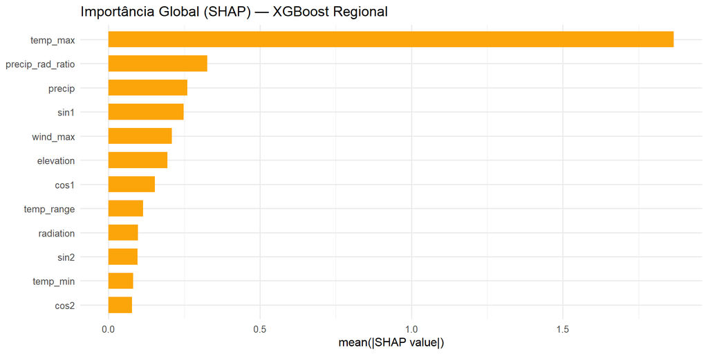

```r
library(shapviz)
X_te_reg <- bake(prep(rec_x), test_reg, all_predictors()) |> as.matrix()
shap_reg <- shapviz(extract_fit_engine(xgb_fit_reg), X_pred = X_te_reg)
sv_importance(shap_reg, kind = "bar", max_display = 12) +
  labs(title = "Importância Global (SHAP) — XGBoost Regional") +
  theme_minimal(base_size = 12)
```

## 3.5 Resultados e Comparação dos Modelos

Com todos os modelos apresentados, agora comparamos o desempenho. Para o negócio, a escolha **não** se baseia só no menor erro: o modelo precisa também **capturar os dias de estresse** (recall do alerta ≥ 35 °C). A tabela traz **erro** (RMSE/MAE/R²) **e** **qualidade do alerta** (recall, precisão) por modelo.

**NoteComo as métricas são calculadas**

RMSE/MAE/R² são **agregados sobre as 11.680 observações dos 16 municípios juntas** (não a média dos 16 RMSEs por município — esse recorte está em O Modelo Generaliza?). Recall e precisão referem-se ao **alerta de estresse** (`temp_max ≥ 35 °C`) sobre esse mesmo teste.

**Ver código**

```r
THR_A <- 35
alert_rp <- function(pred) {
  ra <- factor(if_else(test_reg$target >= THR_A, "Estresse", "Normal"), levels = c("Estresse","Normal"))
  pa <- factor(if_else(pred           >= THR_A, "Estresse", "Normal"), levels = c("Estresse","Normal"))
  list(rec  = yardstick::recall_vec(ra, pa),
       prec = tryCatch(yardstick::precision_vec(ra, pa), error = function(e) NA_real_))
}
preds_reg <- list("Regressão Linear" = p_lin, "Random Forest" = p_rf, "XGBoost (tuned)" = p_xgb,
                  "Ensemble (Reg. Linear + XGBoost)" = p_ens)
if (exists("p_mlp")) preds_reg[["Rede Neural (MLP)"]] <- p_mlp

res_reg <- purrr::imap_dfr(preds_reg, function(p, nm) {
  a <- alert_rp(p)
  tibble(Modelo = nm, RMSE = rmse(p, test_reg$target), MAE = mae(p, test_reg$target),
         R2 = r2(p, test_reg$target), Recall = a$rec, `Precisão` = a$prec)
}) |> mutate(across(where(is.numeric), \(x) round(x, 3)))

res_reg |> arrange(RMSE) |>
  knitr::kable(caption = sprintf(
    "Modelos regionais — erro e qualidade do alerta de estresse (≥ %d °C), teste 2023–2024 (11.680 obs.)", THR_A))
```

Modelos regionais — erro e qualidade do alerta de estresse (≥ 35 °C), teste 2023–2024 (11.680 obs.)

| Modelo | RMSE | MAE | R2 | Recall | Precisão |
| --- | --- | --- | --- | --- | --- |
| Rede Neural (MLP) | 1.641 | 1.213 | 0.730 | 0.596 | 0.865 |
| Ensemble (Reg. Linear + XGBoost) | 1.704 | 1.305 | 0.739 | 0.488 | 0.916 |
| Regressão Linear | 1.717 | 1.317 | 0.731 | 0.452 | 0.899 |
| Random Forest | 1.770 | 1.354 | 0.726 | 0.479 | 0.920 |
| XGBoost (tuned) | 1.779 | 1.338 | 0.715 | 0.509 | 0.902 |

**ImportantEscolha do modelo — por erro **e** por recall**

Não basta o menor erro: o modelo precisa **capturar dias de estresse**. Menor **RMSE**: **Rede Neural (MLP)** (1.641 °C, recall 60%). Maior **recall**: **Rede Neural (MLP)** (recall 60%, RMSE 1.641 °C). Combinando os dois critérios (ranking de RMSE + ranking de recall), a escolha mais equilibrada é o **Rede Neural (MLP)** (RMSE 1.641 °C, recall 60%, precisão 86%) — bom erro **e** boa cobertura dos eventos. O recall ainda é limitado pelo limiar fixo de 35 °C; a camada de decisão mostra como elevá-lo.

**NotePor que os modelos ficam tão próximos — e o boosting não domina**

### 3.5.1 Benchmarks Ingênuos — Persistência e ARIMA

Dois **benchmarks ingênuos** delimitam o que o modelo regional precisa superar:

- **Persistência** (*amanhã = hoje*): a referência **justa** e mais difícil de bater, porque a máxima tem forte inércia diária. É o piso honesto para uma previsão de 1 dia.
- **ARIMA(p,d,q) multi-step**: modela cada série municipal só com termos autorregressivos e de média móvel — **sem clima nem geografia**. Ajustamos um ARIMA **por município** no treino e prevemos **todo o horizonte de teste de uma vez** (multi-step de ~2 anos). É deliberadamente um **limite inferior**: numa previsão multi-step longa o ARIMA converge para o ciclo sazonal e **não** é um competidor de 1 passo — serve para mostrar quanto se perde usando só a história da série, sem covariáveis.

**Ver código**

```r
arima_tr   <- feat_reg |> filter(date < cutoff) |> select(city, date, temp = target) |>
  as_tsibble(index = date, key = city)
arima_fits <- arima_tr |> model(ARIMA = ARIMA(temp ~ PDQ(0, 0, 0)))
hmax       <- test_reg |> count(city) |> pull(n) |> max()
arima_pred <- arima_fits |> forecast(h = hmax) |> as_tibble() |> select(city, date, .mean)
arima_join <- test_reg |> select(city, date, target) |> left_join(arima_pred, by = c("city","date"))
rmse_arima <- rmse(arima_join$.mean, arima_join$target)

# Baseline JUSTO: persistência (amanhã = máxima de hoje)
p_persist    <- test_reg$temp_max
rmse_persist <- rmse(p_persist, test_reg$target)

cat(sprintf(paste0("Persistência (amanhã=hoje) — RMSE = %.3f °C\n",
                   "ARIMA (multi-step, 16 munic.) — RMSE = %.3f °C\n",
                   "Modelo Regional (ensemble)    — RMSE = %.3f °C\n"),
            rmse_persist, rmse_arima, rmse(p_ens, test_reg$target)))
```

```
Persistência (amanhã=hoje) — RMSE = 1.790 °C
ARIMA (multi-step, 16 munic.) — RMSE = 4.102 °C
Modelo Regional (ensemble)    — RMSE = 1.704 °C
```

**Ver código**

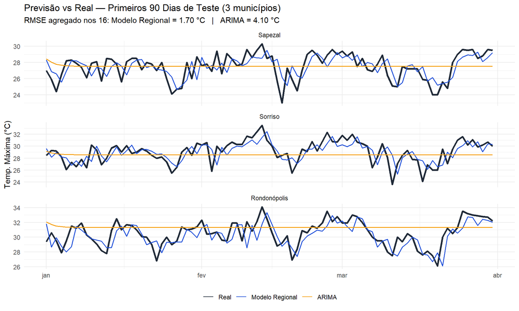

Figure 9: Primeiros 90 dias de teste em três municípios (oeste ameno / centro / sul quente). O modelo regional acompanha as variações diárias; o ARIMA converge para o ciclo médio e perde o dia a dia.

```r
mun_ex  <- c("Sapezal", "Sorriso", "Rondonópolis")
plot_df <- test_reg |> mutate(`Modelo Regional` = p_ens) |>
  select(city, date, Real = target, `Modelo Regional`) |>
  left_join(arima_pred |> rename(ARIMA = .mean), by = c("city","date")) |>
  filter(city %in% mun_ex) |> group_by(city) |> arrange(date) |> slice_head(n = 90) |> ungroup() |>
  mutate(city = factor(city, levels = mun_ex)) |>
  pivot_longer(c(Real, `Modelo Regional`, ARIMA), names_to = "Modelo", values_to = "Temp") |>
  mutate(Modelo = factor(Modelo, levels = c("Real","Modelo Regional","ARIMA")))
ggplot(plot_df, aes(date, Temp, color = Modelo, linewidth = Modelo == "Real")) +
  geom_line() +
  facet_wrap(~city, ncol = 1, scales = "free_y") +
  scale_color_manual(values = c("Real" = "#1F2937", "Modelo Regional" = "#1D4ED8", "ARIMA" = "#F59E0B")) +
  scale_linewidth_manual(values = c("TRUE" = 1.1, "FALSE" = 0.7), guide = "none") +
  labs(title = "Previsão vs Real — Primeiros 90 Dias de Teste (3 municípios)",
       subtitle = sprintf("RMSE agregado nos 16: Modelo Regional = %.2f °C   |   ARIMA = %.2f °C",
                          rmse(p_ens, test_reg$target), rmse_arima),
       x = NULL, y = "Temp. Máxima (°C)", color = NULL) +
  theme_minimal(base_size = 11) + theme(legend.position = "bottom")
```

**NoteComparação justa: o que o modelo realmente precisa bater**

O ARIMA multi-step (**4.10 °C**) é um **limite inferior por construção** — ao prever ~2 anos só com a história da série, colapsa no ciclo sazonal. A comparação **justa** é contra a **persistência** (*amanhã = hoje*, **1.79 °C**): como a máxima tem forte inércia, esse baseline já é forte. O modelo regional (**1.70 °C**) **supera a persistência** usando **clima de hoje + Fourier + geografia** para antecipar as *viradas* que a persistência erra — e é esse ganho (**−0.09 °C** sobre o baseline justo), não a distância para o ARIMA, que mede o valor do aprendizado supervisionado.

### 3.5.2 Comparação Visual — Erro e Recall

**Ver código**

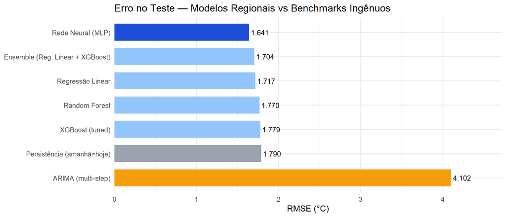

Figure 10: RMSE de teste por modelo (agregado nos 16 municípios), com os benchmarks ingênuos: persistência (cinza, *amanhã=hoje*) e ARIMA multi-step (laranja). Barras menores = melhor.

```r
bind_rows(res_reg |> select(Modelo, RMSE),
          tibble(Modelo = c("Persistência (amanhã=hoje)", "ARIMA (multi-step)"),
                 RMSE   = round(c(rmse_persist, rmse_arima), 3))) |>
  mutate(grupo = case_when(Modelo == "ARIMA (multi-step)"         ~ "arima",
                           Modelo == "Persistência (amanhã=hoje)" ~ "persist",
                           RMSE == min(RMSE)                       ~ "melhor",
                           TRUE                                    ~ "modelo"),
         Modelo = reorder(Modelo, -RMSE)) |>
  ggplot(aes(RMSE, Modelo, fill = grupo)) +
  geom_col(width = 0.7) +
  geom_text(aes(label = sprintf("%.3f", RMSE)), hjust = -0.1, size = 3.6) +
  scale_fill_manual(values = c("modelo" = "#93C5FD", "melhor" = "#1D4ED8",
                               "arima" = "#F59E0B", "persist" = "#9CA3AF"), guide = "none") +
  scale_x_continuous(expand = expansion(mult = c(0, 0.15))) +
  labs(title = "Erro no Teste — Modelos Regionais vs Benchmarks Ingênuos", x = "RMSE (°C)", y = NULL) +
  theme_minimal(base_size = 12)
```

**Ver código**

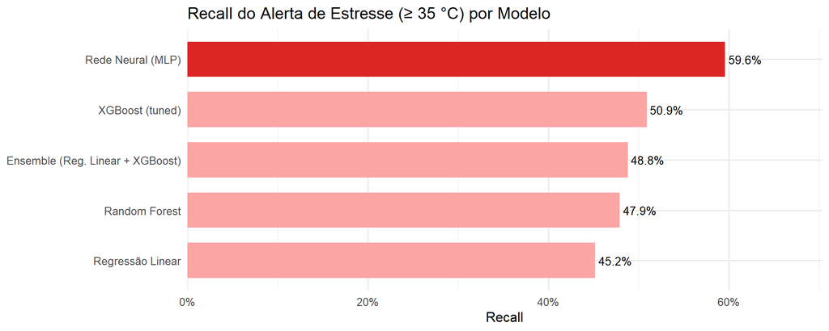

Figure 11: Recall do alerta de estresse (temp_max ≥ 35 °C) por modelo — fração dos dias de estresse que cada modelo captura. Maior = melhor para o negócio (menos quebras de safra não antecipadas).

```r
res_reg |>
  mutate(destaque = Recall == max(Recall), Modelo = reorder(Modelo, Recall)) |>
  ggplot(aes(Recall, Modelo, fill = destaque)) +
  geom_col(width = 0.7) +
  geom_text(aes(label = scales::percent(Recall, accuracy = 0.1)), hjust = -0.1, size = 3.6) +
  scale_fill_manual(values = c("FALSE" = "#FCA5A5", "TRUE" = "#DC2626"), guide = "none") +
  scale_x_continuous(labels = scales::percent, expand = expansion(mult = c(0, 0.18))) +
  labs(title = "Recall do Alerta de Estresse (≥ 35 °C) por Modelo", x = "Recall", y = NULL) +
  theme_minimal(base_size = 12)
```

### 3.5.3 Incerteza — Intervalos de Confiança Bootstrap do RMSE

As diferenças de RMSE entre os modelos são pequenas (faixa de ~0,1 °C). Para saber se são **estatisticamente distinguíveis** ou apenas ruído amostral, reamostramos o conjunto de teste com reposição (*bootstrap*, B = 1000) e recalculamos o RMSE de cada modelo em cada réplica, obtendo intervalos de 95%.

**Ver código**

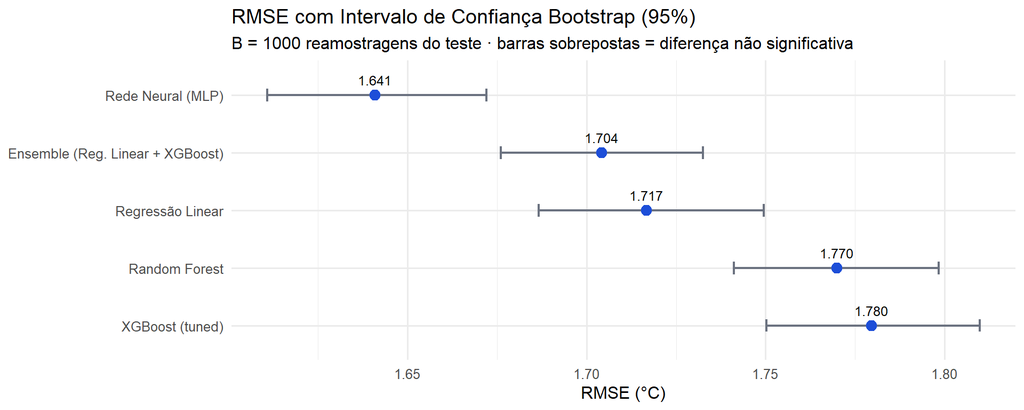

Figure 12: RMSE de teste com intervalo de confiança bootstrap de 95% (B = 1000). Quando as barras horizontais se sobrepõem, a diferença de RMSE entre os modelos não é estatisticamente distinguível.

```r
set.seed(1)
B <- 1000; n_te <- nrow(test_reg); y_te <- test_reg$target
boot_idx <- replicate(B, sample.int(n_te, n_te, replace = TRUE), simplify = FALSE)
boot_reg <- purrr::imap_dfr(preds_reg, function(p, nm) {
  vals <- vapply(boot_idx, function(ix) rmse(p[ix], y_te[ix]), numeric(1))
  tibble(Modelo = nm, RMSE = mean(vals),
         lo = unname(quantile(vals, 0.025)), hi = unname(quantile(vals, 0.975)))
})
boot_reg |>
  mutate(Modelo = reorder(Modelo, -RMSE)) |>
  ggplot(aes(RMSE, Modelo)) +
  geom_errorbarh(aes(xmin = lo, xmax = hi), height = 0.22, color = "#6B7280", linewidth = 0.8) +
  geom_point(size = 3.2, color = "#1D4ED8") +
  geom_text(aes(label = sprintf("%.3f", RMSE)), vjust = -1, size = 3.3) +
  labs(title = "RMSE com Intervalo de Confiança Bootstrap (95%)",
       subtitle = "B = 1000 reamostragens do teste · barras sobrepostas = diferença não significativa",
       x = "RMSE (°C)", y = NULL) +
  theme_minimal(base_size = 12)
```

**ImportantLeitura da incerteza**

## 3.6 Protocolo Treino / Validação / Teste (80 / 10 / 10)

Até aqui usamos um split **treino / teste** (até 2022 vs 2023–2024). Para selecionar modelos sem contaminar a estimativa final, o protocolo de **três vias** separa os papéis: o **treino** ajusta os parâmetros; a **validação** compara e **escolhe** modelos; o **teste** é tocado **uma única vez**, no vencedor, para uma estimativa imparcial. Mantemos o split **cronológico** (não aleatório), coerente com a previsão em produção.

**Ver código**

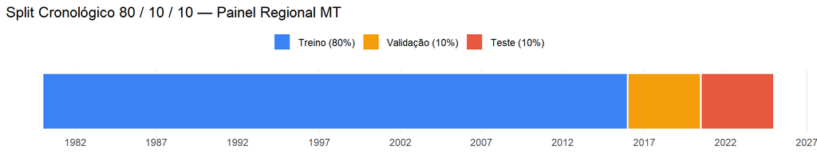

Figure 13: Split cronológico 80/10/10 do painel. O teste (vermelho) é o período mais recente, reservado até a avaliação final do modelo escolhido na validação.

```r
feat3 <- feat_reg |> arrange(date)
n3 <- nrow(feat3); c1 <- floor(0.80 * n3); c2 <- floor(0.90 * n3)
tr3 <- feat3[seq_len(c1), ]; va3 <- feat3[(c1 + 1):c2, ]; te3 <- feat3[(c2 + 1):n3, ]
tibble(Conjunto = factor(c("Treino (80%)","Validação (10%)","Teste (10%)"),
                         levels = c("Treino (80%)","Validação (10%)","Teste (10%)")),
       inicio = as.Date(c(min(tr3$date), min(va3$date), min(te3$date))),
       fim    = as.Date(c(max(tr3$date), max(va3$date), max(te3$date)))) |>
  ggplot() +
  geom_rect(aes(xmin = inicio, xmax = fim, ymin = 0, ymax = 1, fill = Conjunto),
            color = "white", linewidth = 0.8) +
  scale_fill_manual(values = c("Treino (80%)" = "#3B82F6", "Validação (10%)" = "#F59E0B",
                               "Teste (10%)" = "#E8583E")) +
  scale_x_date(date_breaks = "5 years", date_labels = "%Y") +
  labs(title = "Split Cronológico 80 / 10 / 10 — Painel Regional MT", x = NULL, y = NULL, fill = NULL) +
  theme_minimal(base_size = 11) +
  theme(axis.text.y = element_blank(), panel.grid.major.y = element_blank(),
        panel.grid.minor = element_blank(), legend.position = "top")
```

Treinamos os candidatos **só no treino (80%)**, comparamos na **validação (10%)** e confirmamos o vencedor no **teste (10%)**. Para o XGBoost reaproveitamos os hiperparâmetros já selecionados por CV.

**Ver código**

```r
sel3 <- function(df) df |> select(all_of(c(feats_reg, "target")))
rec3  <- recipe(target ~ ., data = sel3(tr3)) |> step_zv(all_predictors()) |> step_normalize(all_numeric_predictors())
rec3x <- recipe(target ~ ., data = sel3(tr3)) |> step_zv(all_predictors())
lin3 <- workflow(rec3,  lin_spec) |> fit(sel3(tr3))
set.seed(1); rf3 <- workflow(rec3, rf_spec) |> fit(sel3(tr3))
xgb3 <- workflow(rec3x, xgb_spec) |> finalize_workflow(best_xgb) |> fit(sel3(tr3))

avalia <- function(df, etapa) {
  pl <- predict(lin3, df)$.pred; pr <- predict(rf3, df)$.pred; px <- predict(xgb3, df)$.pred
  tibble(Modelo = c("Regressão Linear","Random Forest","XGBoost","Ensemble (RL+XGB)"),
         RMSE = c(rmse(pl, df$target), rmse(pr, df$target), rmse(px, df$target), rmse((pl + px) / 2, df$target)),
         Etapa = etapa)
}
val_s  <- avalia(va3, "Validação"); test_s <- avalia(te3, "Teste")
melhor <- val_s |> slice_min(RMSE, n = 1) |> pull(Modelo)

val_s |> select(Modelo, `RMSE validação` = RMSE) |>
  left_join(test_s |> select(Modelo, `RMSE teste` = RMSE), by = "Modelo") |>
  arrange(`RMSE validação`) |>
  mutate(across(where(is.numeric), \(x) round(x, 3)),
         Seleção = if_else(Modelo == melhor, "★", "")) |>
  knitr::kable(caption = "Seleção na validação, confirmação no teste held-out. ★ = modelo escolhido sem olhar o teste.")
```

Seleção na validação, confirmação no teste held-out. ★ = modelo escolhido sem olhar o teste.

| Modelo | RMSE validação | RMSE teste | Seleção |
| --- | --- | --- | --- |
| Ensemble (RL+XGB) | 1.479 | 1.689 | ★ |
| Random Forest | 1.483 | 1.741 |  |
| XGBoost | 1.503 | 1.779 |  |
| Regressão Linear | 1.544 | 1.714 |  |

**TipO que o protocolo de 3 vias entrega**

Ele **não reduz** o RMSE de nenhum modelo; entrega uma **estimativa imparcial** e uma seleção sem contaminar o teste. O ganho de desempenho real vem da validação usada *dentro* do treino — o **tuning do XGBoost por CV** e o **early stopping da MLP**. Esta seção torna esse princípio explícito para a comparação entre algoritmos.

## 3.7 O Modelo Generaliza? RMSE por Município

**Ver código**

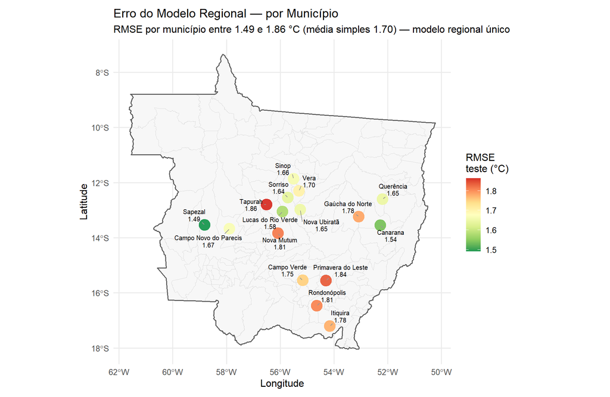

RMSE de teste por município, usando o ÚNICO modelo regional (ensemble). Verde = erro baixo. A faixa estreita mostra que o modelo serve todo o estado, não só um ponto.

```r
percity <- test_reg |> mutate(pred = p_ens) |> group_by(city) |>
  summarise(rmse = rmse(pred, target), .groups = "drop") |> left_join(panel_meta, by = "city")

ggplot(percity, aes(lon, lat)) +
  base_mt +
  geom_point(aes(color = rmse), size = 6, alpha = 0.95) +
  geom_text_repel(aes(label = sprintf("%s\n%.2f", city, rmse)), size = 2.7,
                  lineheight = 0.9, segment.color = "gray60", min.segment.length = 0,
                  max.overlaps = 20, seed = 1) +
  scale_color_distiller(palette = "RdYlGn", direction = -1, name = "RMSE\nteste (°C)") +
  coord_sf(expand = TRUE) +
  labs(title = "Erro do Modelo Regional — por Município",
       subtitle = sprintf("RMSE por município entre %.2f e %.2f °C (média simples %.2f) — modelo regional único",
                          min(percity$rmse), max(percity$rmse), mean(percity$rmse)),
       x = "Longitude", y = "Latitude") +
  theme_minimal(base_size = 12) +
  theme(panel.grid.minor = element_blank(), plot.margin = margin(10, 30, 10, 10))
```

## 3.8 Camada de Decisão — Alerta de Estresse Térmico

A regressão entrega a máxima prevista; o negócio precisa de uma **decisão**: disparar o alerta de risco de safra? Aplicamos um **limiar operacional de 35 °C** sobre a previsão do **ensemble**. Com 16 municípios, o teste tem **milhares** de dias de estresse — as métricas do alerta são estatisticamente robustas.

**ImportantPor que 35 °C é o problema**

Para **soja e milho**, máximas acima de **~35 °C** durante a **floração** e o **enchimento de grãos** são fisiologicamente críticas: reduzem a **viabilidade do pólen** (esterilidade), aumentam o **aborto de flores e vagens** e derrubam a **fotossíntese** e a taxa de enchimento — traduzindo-se em **queda de produtividade**. Por isso 35 °C é o limiar de estresse usado tanto nos **mapas de risco** (Análise Exploratória) quanto neste **alerta** — diagnóstico e decisão no mesmo critério.

**Ver código**

```r
THR <- 35
labf <- function(x) factor(if_else(x >= THR, "Estresse", "Normal"), levels = c("Estresse","Normal"))
dec_reg <- tibble(real = labf(test_reg$target), pred = labf(p_ens))

cm_reg <- yardstick::conf_mat(dec_reg, truth = real, estimate = pred); cm_reg
```

```
          Truth
Prediction Estresse Normal
  Estresse      805     74
  Normal        845   9956
```

**Ver código**

```r
cat(sprintf("\nDias de estresse no teste: %s\n", format(sum(test_reg$target >= THR), big.mark=".")))
```

```
Dias de estresse no teste: 1.650
```

**Ver código**

```r
metric_set(yardstick::precision, yardstick::recall, yardstick::f_meas)(
  dec_reg, truth = real, estimate = pred) |>
  transmute(Métrica = dplyr::recode(.metric, precision = "Precisão", recall = "Recall", f_meas = "F1"),
            Valor = round(.estimate, 3)) |>
  knitr::kable(caption = sprintf("Alerta regional de estresse (temp_max ≥ %d °C) — teste 2023–2024", THR))
```

Alerta regional de estresse (temp_max ≥ 35 °C) — teste 2023–2024

| Métrica | Valor |
| --- | --- |
| Precisão | 0.916 |
| Recall | 0.488 |
| F1 | 0.637 |

**Ver código**

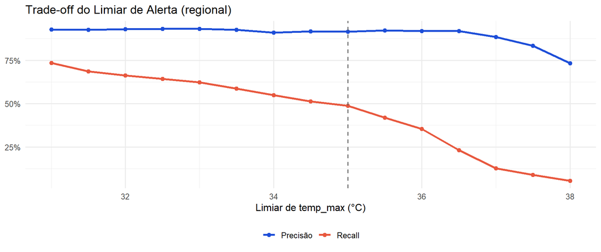

Figure 14: Trade-off precisão × recall do limiar de alerta. Limiar mais baixo captura mais estresse (recall) ao custo de mais falsos alarmes (precisão).

```r
sweep <- purrr::map_dfr(seq(31, 38, 0.5), function(t) {
  ra <- factor(if_else(test_reg$target >= t, "Estresse", "Normal"), levels = c("Estresse","Normal"))
  pa <- factor(if_else(p_ens          >= t, "Estresse", "Normal"), levels = c("Estresse","Normal"))
  tibble(limiar = t,
         Precisão = tryCatch(yardstick::precision_vec(ra, pa), error = function(e) NA_real_),
         Recall   = tryCatch(yardstick::recall_vec(ra, pa),    error = function(e) NA_real_))
})
sweep |> pivot_longer(c(Precisão, Recall), names_to = "Métrica", values_to = "v") |>
  ggplot(aes(limiar, v, color = Métrica)) +
  geom_line(linewidth = 1.1) + geom_point(size = 2) +
  geom_vline(xintercept = THR, linetype = "dashed", color = "gray40") +
  scale_color_manual(values = c("Precisão" = "#1D4ED8", "Recall" = "#E8583E")) +
  scale_y_continuous(labels = scales::percent) +
  labs(title = "Trade-off do Limiar de Alerta (regional)", x = "Limiar de temp_max (°C)",
       y = NULL, color = NULL) +
  theme_minimal(base_size = 12) + theme(legend.position = "bottom")
```

**TipLeitura de negócio**

Para o agente de commodities, **recall** e **precisão** têm custos assimétricos: um estresse perdido é uma quebra de safra não antecipada; um falso alarme custa uma ação operacional à toa. Como a quebra costuma doer mais, a política tende a **privilegiar recall** baixando o limiar — e agora isso é calibrado sobre **milhares de eventos** e válido para **toda a região produtora**, não apenas um município.

**ImportantO recall do alerta ainda é baixo — como melhorar (próximos passos)**

Capturar apenas parte dos dias de estresse não basta para uso operacional. Vias concretas para elevar o recall, da mais simples à mais sofisticada:

1. **Calibrar o limiar para o objetivo de negócio.** O corte de 35 °C é agronômico, não ótimo para *detecção*. O gráfico de trade-off mostra que **baixar o limiar** (ex.: 33–34 °C) eleva bastante o recall ao custo de mais falsos alarmes — escolhe-se o ponto por uma métrica que prioriza recall, como **F-β (β > 1)** ou “máximo recall com precisão ≥ X”.
2. **Tratar o desbalanceamento com um classificador dedicado.** Em vez de regressão + limiar, treinar um **classificador** com **pesos de classe / aprendizado sensível a custo** ou reamostragem (**SMOTE**/oversampling dos dias de estresse), penalizando o **falso negativo** (estresse perdido) mais que o falso alarme.
3. **Prever a distribuição, não só a média.** **Regressão quantílica** (prever o quantil 0,9 da máxima) ou usar o desvio dos resíduos para estimar **P(temp_max ≥ 35 °C)** e alertar quando essa probabilidade cruza um corte — captura melhor a cauda quente.
4. **Features de precursores de onda de calor.** Adicionar **persistência** (lag da própria máxima, sequência de dias secos), umidade do solo e índices sinóticos/**ENSO** — sinais que antecedem extremos e hoje faltam ao modelo.
5. **Mais exemplos na cauda.** Incluir os 4 municípios faltantes (20/20) e variáveis/horizontes extras aumenta os casos de estresse para o modelo aprender o regime extremo.

O caminho mais rápido e de maior impacto é o **item 1** (recalibrar o limiar); o de maior ganho estrutural é o **item 2/3** (classificador sensível a custo ou previsão probabilística da cauda).

# 4 Conclusão — Parte Supervisionada

A análise supervisionada é **única e regional**: um só modelo, treinado no painel dos **16 municípios** de MT, prevê a máxima de amanhã para qualquer um deles. O melhor é a **Rede Neural (MLP)** (**RMSE = 1.641 °C**, MAE = 1.213 °C, R² = 0.7300 no teste 2023–2024), seguido de perto pelo **Ensemble (Reg. Linear + XGBoost)** (**1.704 °C**); o intervalo *bootstrap* mostra que a diferença entre os primeiros é **estatisticamente desprezível**, então a escolha final pondera também o **recall** do alerta. Todos batem a **persistência ingênua (1.79 °C)** — clima de hoje + Fourier + geografia agregam sinal além da inércia diária. O modelo **generaliza** para todo o estado (RMSE por município na faixa estreita do mapa) e sustenta o **alerta de estresse térmico** — robusto para toda a cadeia produtora.

# 5 Parte II — Abordagem Não-Supervisionada

Diferente da Parte I, aqui **não existe alvo**: queremos descobrir a estrutura intrínseca dos dados climáticos de múltiplas cidades. A pergunta passa a ser:

> *Quais cidades têm perfis climáticos similares? Existem zonas climáticas naturais no Brasil?*

Neste contexto, o **PCA e o clustering deixam de ser ferramentas intermediárias e passam a ser os próprios modelos** — o resultado final são os eixos de variação e os agrupamentos que emergem dos dados, sem nenhum rótulo externo.

## 5.1 Dados — Open-Meteo ERA5 (12 Cidades, Diário → Mensal)

**Ver código**

```r
cities <- tribble(
  ~city,             ~region,         ~lon,    ~lat,
  "Manaus",          "Norte",        -60.02,  -3.10,
  "Belém",           "Norte",        -48.48,  -1.46,
  "Recife",          "Nordeste",     -34.88,  -8.05,
  "Fortaleza",       "Nordeste",     -38.54,  -3.72,
  "Salvador",        "Nordeste",     -38.51, -12.97,
  "Brasília",        "Centro-Oeste", -47.93, -15.78,
  "Cuiabá",          "Centro-Oeste", -56.10, -15.60,
  "São Paulo",       "Sudeste",      -46.63, -23.55,
  "Rio de Janeiro",  "Sudeste",      -43.18, -22.91,
  "Belo Horizonte",  "Sudeste",      -43.94, -19.92,
  "Porto Alegre",    "Sul",          -51.23, -30.03,
  "Curitiba",        "Sul",          -49.27, -25.43
)
```

**Ver código**

```r
climate_df <- read_csv("data/brazil_monthly.csv", show_col_types = FALSE) |>
  left_join(cities |> select(city, lon, lat), by = "city") |>
  mutate(
    date       = make_date(year, month, 1),
    temp_range = temp_max - temp_min,
    season = case_when(
      month %in% c(12,1,2)  ~ "Verão",
      month %in% c(3,4,5)   ~ "Outono",
      month %in% c(6,7,8)   ~ "Inverno",
      month %in% c(9,10,11) ~ "Primavera"
    ),
    season = factor(season, levels = c("Verão","Outono","Inverno","Primavera"))
  )

cat(sprintf("Dataset: %d linhas | %d cidades | %d anos\n",
            nrow(climate_df), n_distinct(climate_df$city), n_distinct(climate_df$year)))
```

```
Dataset: 6480 linhas | 12 cidades | 45 anos
```

**Note**

**Pipeline de dados separado:** o script `fetch_data.py` coleta dados diários do Open-Meteo ERA5 para as 12 cidades em janelas de 2 anos (cache incremental em `data/chunks/`), agrega para resolução mensal (média para temperaturas/vento/radiação, soma para precipitação) e salva em `data/brazil_monthly.csv`. Assim o relatório renderiza em segundos sem depender de chamadas de API.

## 5.2 Análise Exploratória Multi-Cidades

**Ver código**

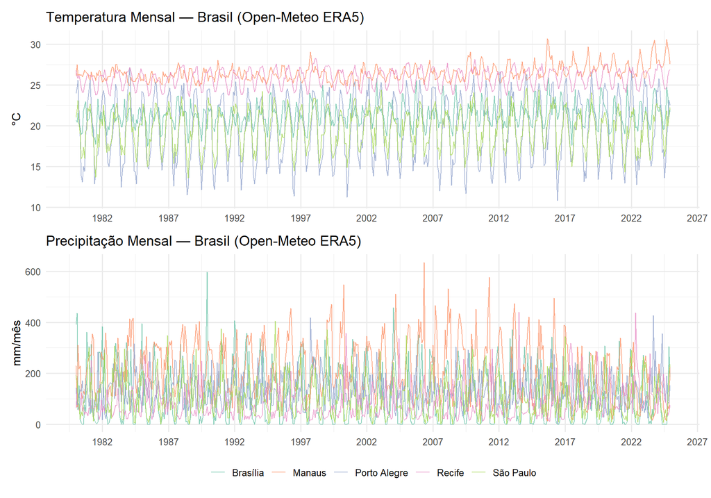

Figure 15: Séries mensais de temperatura e precipitação para 5 cidades representativas (1980–2024). Manaus e Recife quase sem sazonalidade térmica; Porto Alegre com forte ciclo anual.

```r
cities_sel <- c("Manaus","Recife","Brasília","São Paulo","Porto Alegre")

p_t <- climate_df |>
  filter(city %in% cities_sel) |>
  ggplot(aes(date, temp, color = city)) +
  geom_line(alpha = 0.75, linewidth = 0.4) +
  scale_color_brewer(palette = "Set2") +
  scale_x_date(date_breaks = "5 years", date_labels = "%Y") +
  labs(title = "Temperatura Mensal — Brasil (Open-Meteo ERA5)",
       x = NULL, y = "°C", color = NULL) +
  theme_minimal(base_size = 12)

p_p <- climate_df |>
  filter(city %in% cities_sel) |>
  ggplot(aes(date, precip, color = city)) +
  geom_line(alpha = 0.75, linewidth = 0.4) +
  scale_color_brewer(palette = "Set2") +
  scale_x_date(date_breaks = "5 years", date_labels = "%Y") +
  labs(title = "Precipitação Mensal — Brasil (Open-Meteo ERA5)",
       x = NULL, y = "mm/mês", color = NULL) +
  theme_minimal(base_size = 12)

(p_t / p_p) + plot_layout(guides = "collect") &
  theme(legend.position = "bottom")
```

**Ver código**

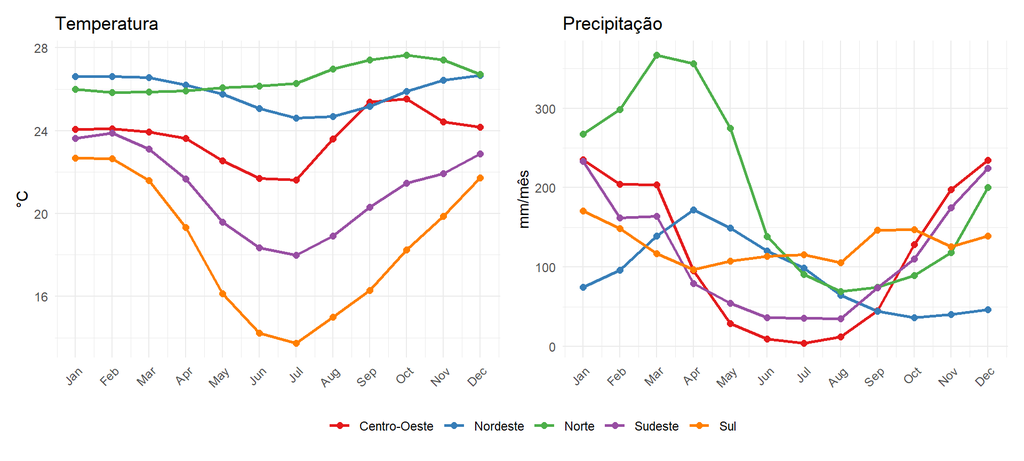

Figure 16: Ciclo sazonal médio por região (1980–2024). O Sul tem a maior amplitude térmica anual; Norte e Centro-Oeste concentram a chuva no verão.

```r
seasonal_long <- climate_df |>
  group_by(region, month) |>
  summarise(temp_m   = mean(temp,   na.rm = TRUE),
            precip_m = mean(precip, na.rm = TRUE), .groups = "drop")

p_st <- seasonal_long |>
  ggplot(aes(month, temp_m, color = region)) +
  geom_line(linewidth = 1) +
  geom_point(size = 2) +
  scale_color_brewer(palette = "Set1") +
  scale_x_continuous(breaks = 1:12, labels = month.abb) +
  labs(title = "Temperatura", x = NULL, y = "°C", color = NULL) +
  theme_minimal(base_size = 11) +
  theme(axis.text.x = element_text(angle = 45, hjust = 1))

p_sp <- seasonal_long |>
  ggplot(aes(month, precip_m, color = region)) +
  geom_line(linewidth = 1) +
  geom_point(size = 2) +
  scale_color_brewer(palette = "Set1") +
  scale_x_continuous(breaks = 1:12, labels = month.abb) +
  labs(title = "Precipitação", x = NULL, y = "mm/mês", color = NULL) +
  theme_minimal(base_size = 11) +
  theme(axis.text.x = element_text(angle = 45, hjust = 1))

(p_st + p_sp) + plot_layout(guides = "collect") &
  theme(legend.position = "bottom")
```

## 5.3 Perfis Climáticos por Cidade

**Ver código**

```r
city_profiles <- climate_df |>
  group_by(city, region) |>
  summarise(
    temp_mean  = mean(temp,       na.rm = TRUE),
    temp_range = mean(temp_range, na.rm = TRUE),
    precip     = mean(precip,     na.rm = TRUE),
    radiation  = mean(radiation,  na.rm = TRUE),
    wind       = mean(wind,       na.rm = TRUE),
    .groups    = "drop"
  )

city_profiles |>
  select(-region) |>
  mutate(across(where(is.numeric), ~round(., 1))) |>
  knitr::kable(caption = "Perfil climático médio por cidade (1980–2024)")
```

Perfil climático médio por cidade (1980–2024)

| city | temp_mean | temp_range | precip | radiation | wind |
| --- | --- | --- | --- | --- | --- |
| Belo Horizonte | 20.5 | 9.6 | 102.3 | 18.6 | 12.4 |
| Belém | 26.6 | 5.8 | 172.4 | 18.6 | 13.4 |
| Brasília | 21.3 | 9.1 | 115.0 | 19.3 | 13.7 |
| Cuiabá | 26.1 | 9.0 | 118.2 | 19.0 | 11.9 |
| Curitiba | 17.4 | 7.8 | 127.2 | 15.2 | 15.8 |
| Fortaleza | 26.6 | 4.8 | 84.7 | 20.9 | 22.9 |
| Manaus | 26.5 | 5.6 | 218.5 | 16.9 | 9.8 |
| Porto Alegre | 19.5 | 8.6 | 128.5 | 16.1 | 17.1 |
| Recife | 25.8 | 4.8 | 81.6 | 19.4 | 17.9 |
| Rio de Janeiro | 23.5 | 7.0 | 133.6 | 17.0 | 11.8 |
| Salvador | 25.2 | 3.3 | 104.0 | 19.7 | 20.2 |
| São Paulo | 19.5 | 8.3 | 110.0 | 16.9 | 16.5 |

## 5.4 PCA Não-Supervisionado — Padrões Climáticos entre Cidades

Na Parte I o PCA era uma **ferramenta** de redução de dimensionalidade a serviço de um alvo externo. Aqui ele **é o modelo**: os eixos de variação separam climaticamente as 12 cidades. A padronização (Z-score) é obrigatória — as variáveis têm unidades diferentes (°C, mm, MJ/m², m/s) e, sem ela, o PCA seria dominado pela variável de maior variância absoluta.

**Ver código**

```r
pca_data <- city_profiles |> column_to_rownames("city") |> select(-region)
X_uns    <- scale(pca_data, center = TRUE, scale = TRUE)
pca_uns  <- prcomp(X_uns)
pca_uns$rotation <- -pca_uns$rotation
pca_uns$x        <- -pca_uns$x

cat("Variância acumulada:\n")
```

```
Variância acumulada:
```

**Ver código**

```r
print(round(cumsum(pca_uns$sdev^2) / sum(pca_uns$sdev^2), 3))
```

```
[1] 0.492 0.811 0.962 0.986 1.000
```

**Ver código**

```r
cat("\nCargas (Phi) — 3 primeiros PCs:\n")
```

```
Cargas (Phi) — 3 primeiros PCs:
```

**Ver código**

```r
print(round(pca_uns$rotation[, 1:3], 3))
```

```
              PC1    PC2    PC3
temp_mean  -0.418 -0.556 -0.242
temp_range  0.476  0.312 -0.583
precip      0.311 -0.646  0.246
radiation  -0.539 -0.024 -0.576
wind       -0.459  0.419  0.458
```

**Ver código**

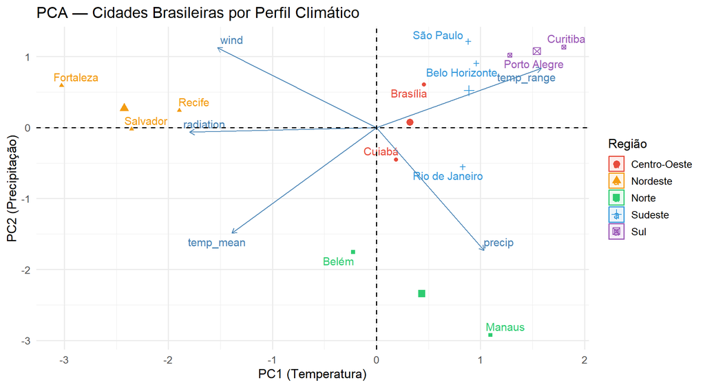

```r
fviz_pca_biplot(pca_uns, repel = TRUE,
  col.ind = city_profiles$region,
  palette = c("#E74C3C","#F39C12","#2ECC71","#3498DB","#9B59B6"),
  addEllipses = TRUE, ellipse.level = 0.70, legend.title = "Região",
  title = "PCA — Cidades Brasileiras por Perfil Climático",
  xlab = "PC1 (Temperatura)", ylab = "PC2 (Precipitação)") +
  theme_minimal(base_size = 13)
```

## 5.5 Clustering — Zonas Climáticas Automáticas

### 5.5.1 Escolha do número de clusters

**Ver código**

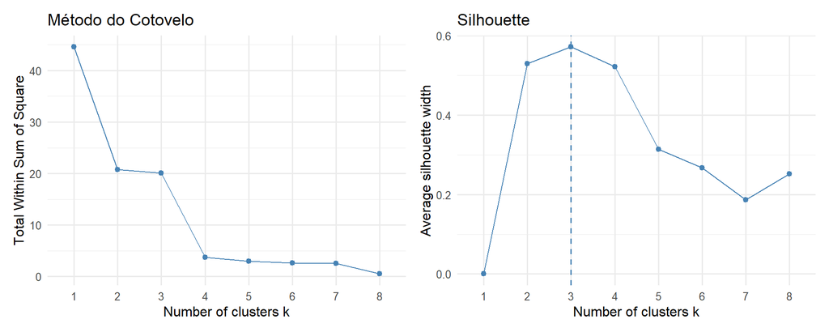

```r
pc_scores <- as.data.frame(pca_uns$x[, 1:2])
k_max <- min(8, nrow(pc_scores) - 1)

p_elbow <- fviz_nbclust(pc_scores, kmeans, method = "wss", k.max = k_max) +
  labs(title = "Método do Cotovelo") + theme_minimal(base_size = 12)

p_silh  <- fviz_nbclust(pc_scores, kmeans, method = "silhouette", k.max = k_max) +
  labs(title = "Silhouette") + theme_minimal(base_size = 12)

p_elbow + p_silh
```

### 5.5.2 K-Means (k = 3)

**Ver código**

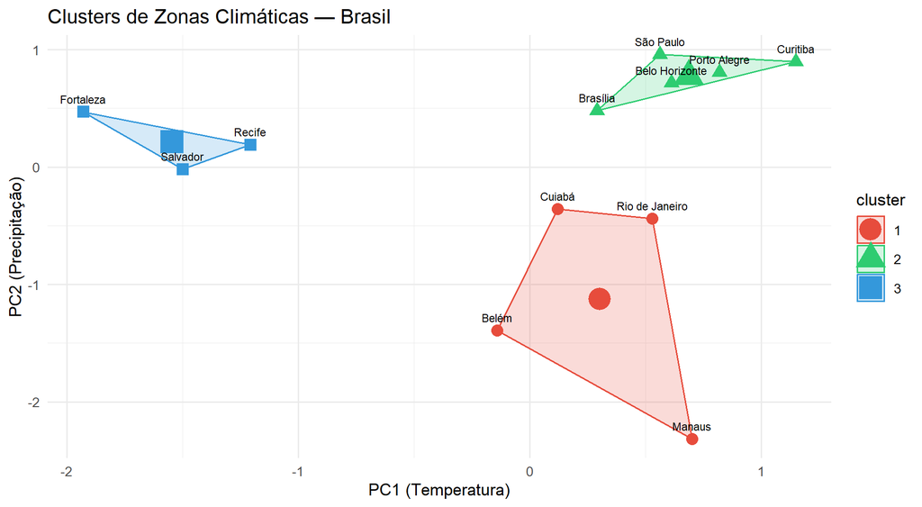

K-Means com k=3 no espaço PC1 × PC2. As 3 zonas resultantes: quente úmida (Norte + Rio de Janeiro + Cuiabá), litorânea do Nordeste (Recife, Fortaleza, Salvador) e amena de subtropical/planalto (Sul/Sudeste + Brasília).

```r
set.seed(42)
km <- kmeans(pc_scores, centers = 3, nstart = 25)
city_profiles$cluster <- as.factor(km$cluster)

fviz_cluster(km, data = pc_scores,
  palette = c("#E74C3C","#2ECC71","#3498DB"),
  geom = "point", ellipse.type = "convex", pointsize = 4,
  main = "Clusters de Zonas Climáticas — Brasil",
  xlab = "PC1 (Temperatura)", ylab = "PC2 (Precipitação)") +
  geom_text(aes(label = rownames(pc_scores)), size=3, vjust=-1, check_overlap = TRUE) +
  theme_minimal(base_size = 13)
```

**Ver código**

```r
city_profiles |>
  group_by(cluster) |>
  summarise(
    Cidades          = paste(city, collapse = ", "),
    `Temp. Média`    = round(mean(temp_mean), 1),
    `Precip. Média`  = round(mean(precip), 1),
    `Radiação Média` = round(mean(radiation), 1),
    N = n(), .groups = "drop"
  ) |>
  knitr::kable(caption = "Perfil médio de cada zona climática (K-Means)")
```

Perfil médio de cada zona climática (K-Means)

| cluster | Cidades | Temp. Média | Precip. Média | Radiação Média | N |
| --- | --- | --- | --- | --- | --- |
| 1 | Belém, Cuiabá, Manaus, Rio de Janeiro | 25.7 | 160.7 | 17.9 | 4 |
| 2 | Belo Horizonte, Brasília, Curitiba, Porto Alegre, São Paulo | 19.6 | 116.6 | 17.2 | 5 |
| 3 | Fortaleza, Recife, Salvador | 25.9 | 90.1 | 20.0 | 3 |

### 5.5.3 Clustering Hierárquico (Ward’s)

**Ver código**

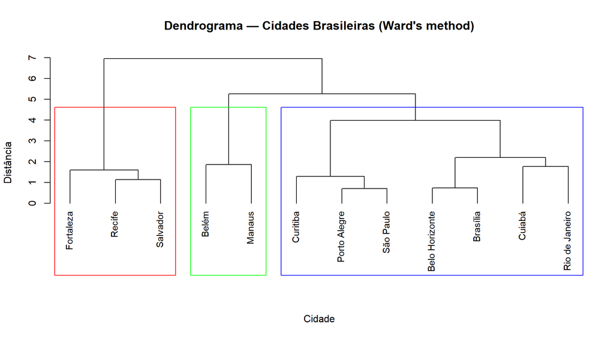

Figure 18: Dendrograma Ward’s: as caixas coloridas indicam o corte em k=3. O hierárquico não exige k a priori e é determinístico — ideal para validar o K-Means.

```r
dist_matrix <- dist(X_uns, method = "euclidean")
hclust_res  <- hclust(dist_matrix, method = "ward.D2")
plot(hclust_res, main = "Dendrograma — Cidades Brasileiras (Ward's method)",
     xlab = "Cidade", ylab = "Distância", sub = "", cex = 0.9, hang = -1)
rect.hclust(hclust_res, k = 3, border = c("red","green","blue"))
```

**Tip**

**K-Means vs Hierárquico:** K-Means é mais eficiente computacionalmente (essencial para n grande), mas requer k a priori e não é determinístico sem `set.seed`. O hierárquico é determinístico, permite visualizar a estrutura de fusão completa, mas tem complexidade O(n²) em memória — inviável para grandes datasets. Com 12 cidades, ambos são triviais; usar os dois e cruzar a interpretação reforça a validade da segmentação.

# 6 Parte III — Os Clusters Estão Mudando?

A estrutura das zonas climáticas brasileiras é estável ou está se reconfigurando? Dividimos os 45 anos em **3 períodos de ~15 anos** e aplicamos o mesmo pipeline PCA + K-Means em cada janela, comparando como as cidades se movem no espaço de componentes e se mudam de cluster.

**Ver código**

```r
climate_periods <- climate_df |>
  mutate(period = case_when(year<=1994~"1980–1994",
                             year<=2009~"1995–2009",
                             TRUE~"2010–2024"),
         period = factor(period, levels=c("1980–1994","1995–2009","2010–2024")))

profiles_temporal <- climate_periods |>
  group_by(city, region, period) |>
  summarise(across(c(temp,temp_range,precip,radiation,wind),
                   ~mean(.x,na.rm=TRUE), .names="{.col}_mean"),
            .groups="drop") |>
  rename(temp_range=temp_range_mean,
         precip=precip_mean, radiation=radiation_mean, wind=wind_mean)
```

## 6.1 PCA e K-Means por Período

**Ver código**

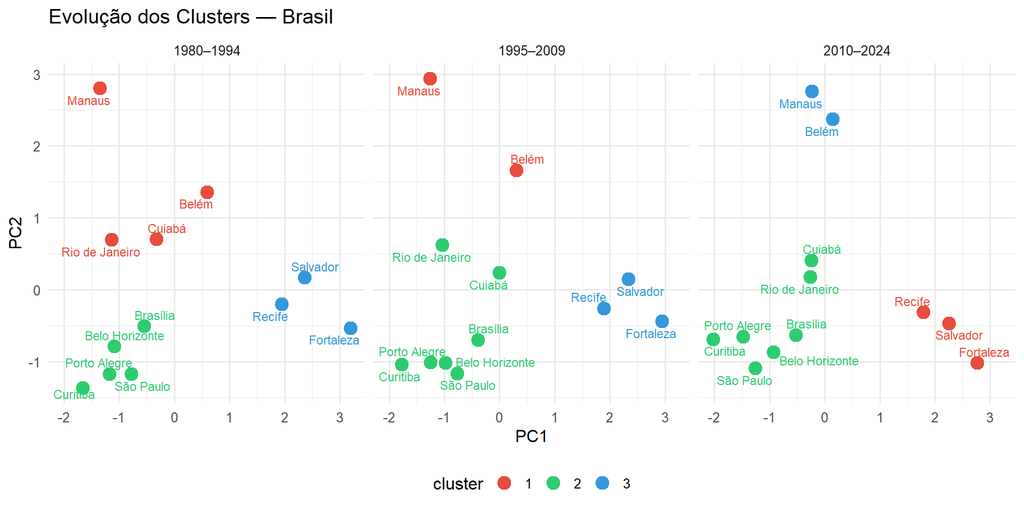

Espaço PCA com K-Means (k=3) para cada período. Movimentação das cidades indica mudança no perfil climático relativo; mudança de cor (cluster) indica reclassificação de zona climática.

```r
run_period_clustering <- function(df, period_label) {
  prof  <- df |> filter(period==period_label) |>
    select(city, temp_mean, temp_range, precip, radiation, wind) |>
    column_to_rownames("city")
  X_s   <- scale(prof)
  pca_p <- prcomp(X_s)
  pc2   <- as.data.frame(pca_p$x[,1:2])
  set.seed(42)
  km_p  <- kmeans(pc2, centers=min(3,nrow(pc2)-1), nstart=25)
  pc2 |> mutate(city=rownames(pc2), cluster=as.factor(km_p$cluster),
                period=period_label)
}

map(levels(profiles_temporal$period),
    ~run_period_clustering(profiles_temporal, .x)) |>
  list_rbind() |>
  ggplot(aes(PC1, PC2, color=cluster, label=city)) +
  geom_point(size=4) +
  ggrepel::geom_text_repel(size=3, max.overlaps=15) +
  facet_wrap(~period) +
  scale_color_manual(values=c("#E74C3C","#2ECC71","#3498DB")) +
  labs(title="Evolução dos Clusters — Brasil", x="PC1", y="PC2") +
  theme_minimal(base_size=12) + theme(legend.position="bottom")
```

## 6.2 Estabilidade dos Clusters — Análise de Migração

Verificamos quais cidades mudam de cluster entre períodos — indicando transição de zona climática. Usamos clustering hierárquico (Ward’s) para consistência de rótulos entre períodos, já que o K-Means sofre de *label-switching*.

**Ver código**

```r
periods <- levels(profiles_temporal$period)

run_hclust_period <- function(df, period_label) {
  prof <- df |> filter(period == period_label) |>
    select(city, temp_mean, temp_range, precip, radiation, wind) |>
    column_to_rownames("city")
  X_s <- scale(prof)
  hc  <- hclust(dist(X_s, method = "euclidean"), method = "ward.D2")
  cl  <- cutree(hc, k = 3)
  tibble(city = names(cl), cluster_h = cl, period = period_label)
}

hc_temporal <- map(periods, ~run_hclust_period(profiles_temporal, .x)) |>
  list_rbind()

hc_temporal |>
  pivot_wider(names_from = period, values_from = cluster_h, names_prefix = "cl_") |>
  left_join(select(cities, city, region), by = "city") |>
  select(city, region, everything()) |>
  knitr::kable(caption = "Atribuição de cluster por período (Ward's, k=3). Mudanças indicam migração climática.")
```

Atribuição de cluster por período (Ward’s, k=3). Mudanças indicam migração climática.

| city | region | cl_1980–1994 | cl_1995–2009 | cl_2010–2024 |
| --- | --- | --- | --- | --- |
| Belo Horizonte | Sudeste | 1 | 1 | 1 |
| Belém | Norte | 1 | 2 | 2 |
| Brasília | Centro-Oeste | 1 | 1 | 1 |
| Cuiabá | Centro-Oeste | 1 | 1 | 1 |
| Curitiba | Sul | 2 | 1 | 1 |
| Fortaleza | Nordeste | 3 | 3 | 3 |
| Manaus | Norte | 1 | 2 | 2 |
| Porto Alegre | Sul | 2 | 1 | 1 |
| Recife | Nordeste | 3 | 3 | 3 |
| Rio de Janeiro | Sudeste | 1 | 2 | 1 |
| Salvador | Nordeste | 3 | 3 | 3 |
| São Paulo | Sudeste | 2 | 1 | 1 |

**Ver código**

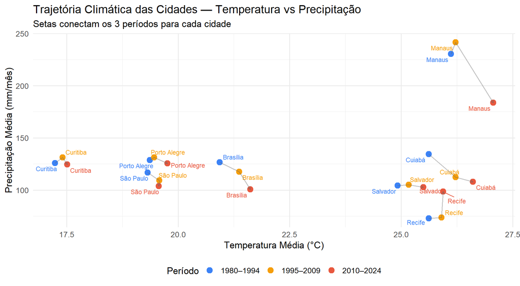

Figure 19: Trajetória de cada cidade no espaço Temperatura × Precipitação. As setas conectam os 3 períodos; cidades que se deslocam muito mudam de perfil climático relativo.

```r
profiles_temporal |>
  filter(city %in% c("Manaus","Recife","Brasília","São Paulo",
                     "Porto Alegre","Curitiba","Cuiabá","Salvador")) |>
  select(city, period, temp_mean, precip) |>
  ggplot(aes(temp_mean, precip, color = period, label = city)) +
  geom_point(size = 3.5) +
  ggrepel::geom_text_repel(size = 3, max.overlaps = 20) +
  geom_path(aes(group = city), arrow = arrow(length = unit(0.15, "cm")),
            alpha = 0.4, linewidth = 0.6, color = "gray40") +
  scale_color_manual(values = c("#3B82F6","#F59E0B","#E8583E")) +
  labs(title    = "Trajetória Climática das Cidades — Temperatura vs Precipitação",
       subtitle = "Setas conectam os 3 períodos para cada cidade",
       x = "Temperatura Média (°C)", y = "Precipitação Média (mm/mês)",
       color = "Período") +
  theme_minimal(base_size = 13) +
  theme(legend.position = "bottom")
```

## 6.3 Distância Intra-Cluster — Os Clusters Estão Ficando Mais Difusos?

Para responder se as zonas climáticas estão ficando **menos nítidas** ao longo do tempo, medimos a qualidade da partição em cada período com **duas métricas complementares** — por isso os dois gráficos:

- **WSS (within-cluster sum of squares)** — soma das distâncias internas de cada cluster ao seu centro. Mede **compactação**: WSS **maior** = pontos mais espalhados dentro do cluster = zonas menos coesas.
- **Silhouette médio** — para cada cidade, compara a distância ao próprio cluster com a distância ao cluster vizinho mais próximo. Mede **separação**: Silhouette **menor** (mais perto de 0) = fronteiras mais ambíguas entre zonas.

A leitura conjunta é o que importa: se, ao longo dos períodos, o **WSS sobe** *e* o **Silhouette cai**, as zonas estão **convergindo** (perfis regionais ficando mais parecidos) — coerente com homogeneização climática. Se ambos se mantêm estáveis, as três zonas são estruturas robustas no tempo.

**Ver código**

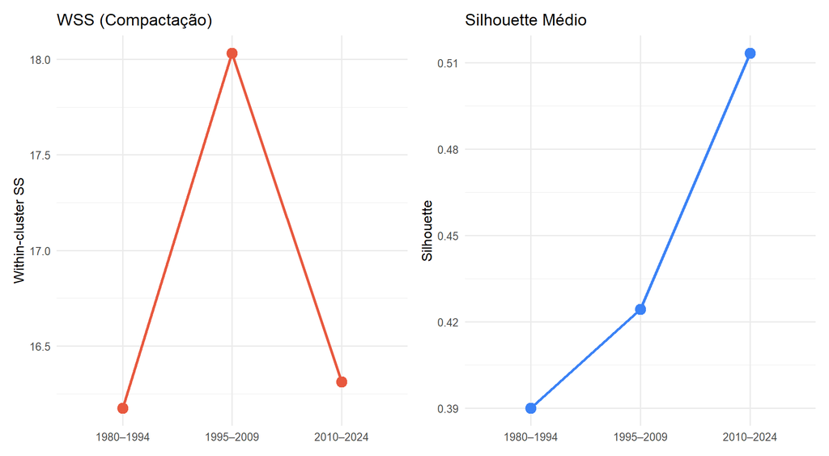

WSS (compactação dos clusters) e Silhouette médio por período. WSS crescente = clusters menos compactos; Silhouette decrescente = pior separação.

```r
compute_cluster_quality <- function(df, period_label) {
  prof <- df |> filter(period == period_label) |>
    select(city, temp_mean, temp_range, precip, radiation, wind) |>
    column_to_rownames("city")
  X_s <- scale(prof)
  set.seed(42)
  km  <- kmeans(X_s, centers = min(3, nrow(X_s) - 1), nstart = 25)
  sil <- silhouette(km$cluster, dist(X_s))
  tibble(period = period_label, wss = km$tot.withinss,
         sil_mean = mean(sil[, "sil_width"]))
}

quality_temporal <- map(periods, ~compute_cluster_quality(profiles_temporal, .x)) |>
  list_rbind() |>
  mutate(period = factor(period, levels = periods))

p_wss <- ggplot(quality_temporal, aes(period, wss, group = 1)) +
  geom_line(linewidth = 1.2, color = "#E8583E") +
  geom_point(size = 4, color = "#E8583E") +
  labs(title = "WSS (Compactação)", x = NULL, y = "Within-cluster SS") +
  theme_minimal(base_size = 12)

p_sil <- ggplot(quality_temporal, aes(period, sil_mean, group = 1)) +
  geom_line(linewidth = 1.2, color = "#3B82F6") +
  geom_point(size = 4, color = "#3B82F6") +
  labs(title = "Silhouette Médio", x = NULL, y = "Silhouette") +
  theme_minimal(base_size = 12)

p_wss + p_sil
```

**Ver código**

```r
quality_temporal |>
  mutate(across(where(is.numeric), ~round(., 3))) |>
  knitr::kable(caption = "Métricas de qualidade dos clusters por período")
```

Métricas de qualidade dos clusters por período

| period | wss | sil_mean |
| --- | --- | --- |
| 1980–1994 | 16.175 | 0.390 |
| 1995–2009 | 18.032 | 0.424 |
| 2010–2024 | 16.312 | 0.513 |

**Note**

**Interpretação da dinâmica dos clusters:** se o WSS aumenta e o Silhouette diminui ao longo dos períodos, os perfis climáticos estão se tornando mais homogêneos entre regiões — possível convergência climática ligada ao aquecimento global. Quando uma cidade muda de cluster, seu microclima está se deslocando em relação aos vizinhos geográficos. A trajetória no espaço Temperatura × Precipitação mostra a direção e a magnitude dessas mudanças.

# 7 Parte IV — Complemento: Agrupando os 16 Municípios de MT

Como complemento que **unifica as duas partes do projeto**, aplicamos o mesmo arsenal não-supervisionado (**PCA + K-Means + Ward**) à **mesma base do modelo supervisionado** — o painel dos 16 municípios de MT. A pergunta deixa de ser sobre o Brasil e passa a ser interna ao estado: *existem **regimes climáticos naturais** entre os municípios produtores?* O resultado dialoga com o mapa de estresse térmico (Análise Exploratória) e com o mapa de RMSE por município (Parte I).

A padronização (Z-score) é obrigatória — as oito variáveis têm unidades distintas. O número de zonas é escolhido por **silhouette** (máxima separação), e **nem latitude nem longitude entram como features**: a geografia que emergir é resultado, não insumo.

**Ver código**

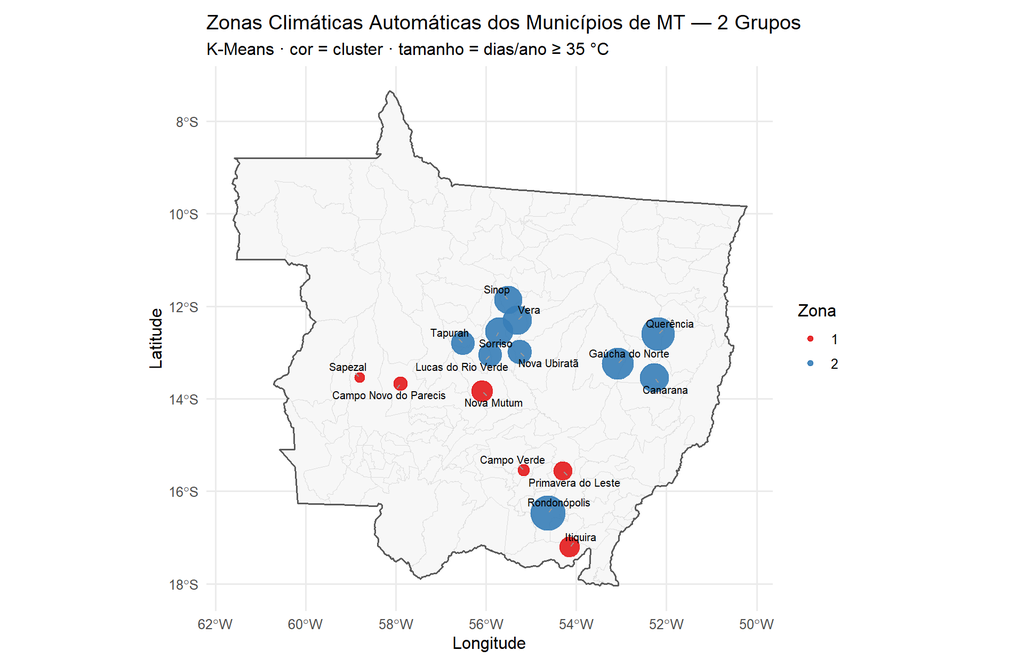

```r
ggplot(mt_profiles, aes(lon, lat)) +
  base_mt +
  geom_point(aes(color = cluster, size = days_ge35), alpha = 0.9) +
  ggrepel::geom_text_repel(aes(label = city), size = 2.7, segment.color = "gray60",
                           min.segment.length = 0, max.overlaps = 20, seed = 1) +
  scale_color_brewer(palette = "Set1", name = "Zona") +
  scale_size_continuous(range = c(3, 11), guide = "none") +
  coord_sf(expand = TRUE) +
  labs(title = sprintf("Zonas Climáticas Automáticas dos Municípios de MT — %d Grupos", k_mt),
       subtitle = "K-Means · cor = cluster · tamanho = dias/ano ≥ 35 °C",
       x = "Longitude", y = "Latitude") +
  theme_minimal(base_size = 12) +
  theme(panel.grid.minor = element_blank(), plot.margin = margin(10, 30, 10, 10))
```

**Ver código**

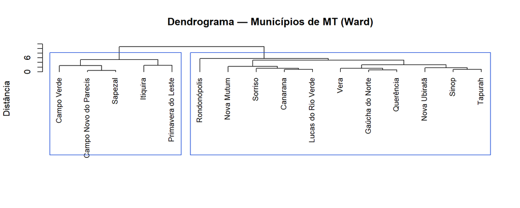

```r
hc_mt <- hclust(dist(X_mt), method = "ward.D2")
plot(hc_mt, main = "Dendrograma — Municípios de MT (Ward)", xlab = "", ylab = "Distância",
     sub = "", cex = 0.85, hang = -1)
rect.hclust(hc_mt, k = k_mt, border = "#1D4ED8")
```

Perfil das 2 zonas dos municípios de MT (K-Means · silhouette 0.49)

| Zona | Municípios | T.máx média (°C) | Dias/ano ≥ 35 °C | Elevação média (m) | N |
| --- | --- | --- | --- | --- | --- |
| 1 | Campo Novo do Parecis, Campo Verde, Itiquira, Nova Mutum, Primavera do Leste, Sapezal | 28.8 | 4 | 589 | 6 |
| 2 | Canarana, Gaúcha do Norte, Lucas do Rio Verde, Nova Ubiratã, Querência, Rondonópolis, Sinop, Sorriso, Tapurah, Vera | 30.4 | 19 | 372 | 10 |

# 8 Conclusão — Parte Não-Supervisionada

- **Quente úmida (cluster de Manaus):** Belém, Cuiabá, Manaus, Rio de Janeiro
- **Litorânea do Nordeste (cluster de Recife):** Fortaleza, Recife, Salvador
- **Amena — subtropical e planalto (cluster de Curitiba):** Belo Horizonte, Brasília, Curitiba, Porto Alegre, São Paulo

Parte do resultado é **o esperado pela proximidade geográfica**: Manaus–Belém e Curitiba–Porto Alegre compartilham zona, e o litoral nordestino forma um grupo próprio. Mas o critério é **climático, não geográfico** — a proximidade ajuda, mas não determina: o **Rio de Janeiro** agrupa com Manaus e Belém (calor o ano todo), e não com a vizinha São Paulo; **Brasília** e **Belo Horizonte**, embora tropicais e distantes do Sul, caem na zona amena — efeito da **altitude** do planalto, não da latitude; **Cuiabá**, no cerrado, junta-se ao calor amazônico apesar da distância.

**Dinâmica (Parte III):** entre 1980–1994 e 2010–2024, o silhouette médio foi de 0.39 para 0.51 e o WSS de 16.2 para 16.3 — a separação entre as zonas **se manteve ou até se fortaleceu** — as três zonas climáticas são estruturas estáveis no tempo. A tabela de migração da Parte III identifica quais cidades trocaram de zona no período.

# 9 Síntese Final

[output not shown]